# DE with EdgeR

```r
library(edgeR)
library(ggplot2)
```

```r
expression <- read.csv('results/expression.csv', header=TRUE, row.names=1)
head(expression)
```

|  | chimp_11454_L1 | chimp_13309_L1 | chimp_j8_L1 | human_759_L1 | human_j12_L1 | human_j3_L1 | human_j4_L1 | human_j6_L1 | macaque_0701_L1 | macaque_0703_L1 | macaque_0704_L1 | macaque_nb0904_L1 | chimp_11454_L2 | chimp_13309_L2 | chimp_j8_L2 | human_759_L2 | human_j12_L2 | human_j3_L2 | human_j4_L2 | human_j6_L2 | macaque_0701_L2 | macaque_0703_L2 | macaque_0704_L2 | macaque_nb0904_L2 | chimp_11454_L3 | chimp_13309_L3 | chimp_j11_L3 | chimp_j8_L3 | human_759_L3 | … |
| --- | --- | --- | --- | --- | --- | --- | --- | --- | --- | --- | --- | --- | --- | --- | --- | --- | --- | --- | --- | --- | --- | --- | --- | --- | --- | --- | --- | --- | --- | --- |
| A1BG | 0.02475247 | 0.004975124 | 0.032663316 | 0.144 | 0.145015100 | 0.19090909 | 0.252100860 | 0.06716418 | 0.003496503 | 0.00000000 | 0.003508772 | 0.000000000 | 0.02994012 | 0.007352941 | 0.06965174 | 0.450738900 | 0.760000000 | 1.47959180 | 0.735042750 | 0.22935780 | 0.008695652 | 0.017587940 | 0.007874016 | 0.02127659 | 0.076167080 | 0.049822062 | 0.1639344 | 0.142091160 | 0.501941740 | … |
| A1CF | 0.00000000 | 0.000000000 | 0.000000000 | 0.002 | 0.000000000 | 0.00000000 | 0.008403362 | 0.00000000 | 0.000000000 | 0.00000000 | 0.000000000 | 0.000000000 | 0.00000000 | 0.000000000 | 0.00000000 | 0.002463054 | 0.000000000 | 0.00000000 | 0.012820513 | 0.00000000 | 0.000000000 | 0.000000000 | 0.000000000 | 0.00000000 | 0.000000000 | 0.000000000 | 0.0000000 | 0.001340483 | 0.012621359 | … |
| A2ML1 | 0.00000000 | 0.000000000 | 0.007537689 | 0.010 | 0.000000000 | 0.00000000 | 0.000000000 | 0.00000000 | 0.000000000 | 0.00000000 | 0.000000000 | 0.000000000 | 0.00000000 | 0.007352941 | 0.00000000 | 0.009852217 | 0.000000000 | 0.00000000 | 0.004273504 | 0.00000000 | 0.000000000 | 0.000000000 | 0.000000000 | 0.00000000 | 0.002457002 | 0.001779359 | 0.0000000 | 0.001340483 | 0.002912621 | … |
| A4GALT | 0.00000000 | 0.000000000 | 0.000000000 | 0.004 | 0.009063444 | 0.00000000 | 0.000000000 | 0.01492537 | 0.034965035 | 0.01020408 | 0.010526316 | 0.009448819 | 0.00000000 | 0.000000000 | 0.00000000 | 0.009852217 | 0.005714286 | 0.01020408 | 0.008547009 | 0.02752294 | 0.030434782 | 0.007537689 | 0.003937008 | 0.01063830 | 0.000000000 | 0.000000000 | 0.0000000 | 0.000000000 | 0.010679612 | … |
| AAAS | 0.05940594 | 0.019900497 | 0.050251257 | 0.056 | 0.048338370 | 0.03636363 | 0.063025214 | 0.07462686 | 0.066433564 | 0.03571429 | 0.017543860 | 0.011023622 | 0.06586827 | 0.044117650 | 0.12437811 | 0.041871920 | 0.177142860 | 0.36734694 | 0.145299150 | 0.24770643 | 0.100000000 | 0.062814070 | 0.031496063 | 0.01418440 | 0.052825550 | 0.088967970 | 0.1202186 | 0.150134040 | 0.044660196 | … |
| AACS | 0.13861386 | 0.099502490 | 0.128140700 | 0.108 | 0.063444110 | 0.15454546 | 0.159663870 | 0.07462686 | 0.545454560 | 0.30102040 | 0.217543860 | 0.165354330 | 0.25149700 | 0.095588240 | 0.39303482 | 0.209359600 | 0.325714300 | 0.60204080 | 0.529914560 | 0.11926606 | 1.517391300 | 0.917085400 | 0.673228300 | 0.29432625 | 0.330466840 | 0.382562280 | 0.3879781 | 0.430294900 | 0.254368930 | … |

```r
annotation <- read.csv("results/annotation.csv", header=TRUE, row.names=1)
head(annotation)
```

|  | layer | sample_id | psbulk_n_cells | psbulk_counts | condition | layer_c |
| --- | --- | --- | --- | --- | --- | --- |
| chimp_11454_L1 | L1 | chimp_11454 | 202 | 360976 | chimp | 1 |
| chimp_13309_L1 | L1 | chimp_13309 | 201 | 313326 | chimp | 1 |
| chimp_j8_L1 | L1 | chimp_j8 | 398 | 862771 | chimp | 1 |
| human_759_L1 | L1 | human_759 | 500 | 961453 | human | 1 |
| human_j12_L1 | L1 | human_j12 | 331 | 827957 | human | 1 |
| human_j3_L1 | L1 | human_j3 | 110 | 378096 | human | 1 |

## Human markers

### Prepare the data

Let’s filter human samples in expression and annotation dataframes

```r
human_ann <- annotation[annotation$condition == 'human',]
head(human_ann)
```

|  | layer | sample_id | psbulk_n_cells | psbulk_counts | condition | layer_c |
| --- | --- | --- | --- | --- | --- | --- |
| human_759_L1 | L1 | human_759 | 500 | 961453 | human | 1 |
| human_j12_L1 | L1 | human_j12 | 331 | 827957 | human | 1 |
| human_j3_L1 | L1 | human_j3 | 110 | 378096 | human | 1 |
| human_j4_L1 | L1 | human_j4 | 238 | 770218 | human | 1 |
| human_j6_L1 | L1 | human_j6 | 134 | 255642 | human | 1 |
| human_759_L2 | L2 | human_759 | 406 | 1458288 | human | 2 |

```r
human_expr <- expression[, row.names(human_ann)]
head(human_expr)
```

|  | human_759_L1 | human_j12_L1 | human_j3_L1 | human_j4_L1 | human_j6_L1 | human_759_L2 | human_j12_L2 | human_j3_L2 | human_j4_L2 | human_j6_L2 | human_759_L3 | human_j12_L3 | human_j3_L3 | human_j4_L3 | human_j6_L3 | human_759_L4 | human_j12_L4 | human_j3_L4 | human_j4_L4 | human_j6_L4 | human_759_L5 | human_j12_L5 | human_j3_L5 | human_j4_L5 | human_j6_L5 | human_759_L6 | human_j12_L6 | human_j3_L6 | human_j4_L6 | … |
| --- | --- | --- | --- | --- | --- | --- | --- | --- | --- | --- | --- | --- | --- | --- | --- | --- | --- | --- | --- | --- | --- | --- | --- | --- | --- | --- | --- | --- | --- | --- |
| A1BG | 0.144 | 0.145015100 | 0.19090909 | 0.252100860 | 0.06716418 | 0.450738900 | 0.760000000 | 1.47959180 | 0.735042750 | 0.22935780 | 0.501941740 | 0.592364550 | 1.8993710 | 1.384835500 | 0.37278107 | 0.468325800 | 0.558441600 | 2.497872400 | 1.129666000 | 0.463190200 | 0.284182300 | 0.43537414 | 2.430493400 | 0.565610900 | 0.522807000 | 0.313761470 | 0.2722772 | 0.985611500 | 0.233618230 | … |
| A1CF | 0.002 | 0.000000000 | 0.00000000 | 0.008403362 | 0.00000000 | 0.002463054 | 0.000000000 | 0.00000000 | 0.012820513 | 0.00000000 | 0.012621359 | 0.006157635 | 0.0000000 | 0.031473532 | 0.00000000 | 0.000000000 | 0.003246753 | 0.000000000 | 0.017681729 | 0.003067485 | 0.000000000 | 0.00000000 | 0.004484305 | 0.002262444 | 0.001754386 | 0.000000000 | 0.0000000 | 0.000000000 | 0.000000000 | … |
| A2ML1 | 0.010 | 0.000000000 | 0.00000000 | 0.000000000 | 0.00000000 | 0.009852217 | 0.000000000 | 0.00000000 | 0.004273504 | 0.00000000 | 0.002912621 | 0.001231527 | 0.0000000 | 0.005722461 | 0.00000000 | 0.015837105 | 0.006493507 | 0.008510638 | 0.005893910 | 0.000000000 | 0.002680965 | 0.01020408 | 0.000000000 | 0.006787330 | 0.001754386 | 0.001834862 | 0.0000000 | 0.007194245 | 0.000000000 | … |
| A4GALT | 0.004 | 0.009063444 | 0.00000000 | 0.000000000 | 0.01492537 | 0.009852217 | 0.005714286 | 0.01020408 | 0.008547009 | 0.02752294 | 0.010679612 | 0.003694581 | 0.0000000 | 0.008583691 | 0.01183432 | 0.004524887 | 0.016233766 | 0.017021276 | 0.009823183 | 0.012269938 | 0.000000000 | 0.02040816 | 0.013452915 | 0.013574661 | 0.008771930 | 0.001834862 | 0.0000000 | 0.007194245 | 0.002849003 | … |
| AAAS | 0.056 | 0.048338370 | 0.03636363 | 0.063025214 | 0.07462686 | 0.041871920 | 0.177142860 | 0.36734694 | 0.145299150 | 0.24770643 | 0.044660196 | 0.160098520 | 0.3459120 | 0.198855500 | 0.15384616 | 0.049773756 | 0.159090900 | 0.255319150 | 0.214145380 | 0.162576690 | 0.045576410 | 0.13605443 | 0.269058300 | 0.108597286 | 0.212280700 | 0.045871560 | 0.1039604 | 0.183453230 | 0.068376070 | … |
| AACS | 0.108 | 0.063444110 | 0.15454546 | 0.159663870 | 0.07462686 | 0.209359600 | 0.325714300 | 0.60204080 | 0.529914560 | 0.11926606 | 0.254368930 | 0.364532020 | 0.7232704 | 0.668097260 | 0.25443786 | 0.260181000 | 0.389610380 | 0.668085100 | 0.675834950 | 0.297546000 | 0.252010730 | 0.38435373 | 0.847533640 | 0.500000000 | 0.380701750 | 0.247706430 | 0.2574258 | 0.348920850 | 0.233618230 | … |

```r
NA
```

Factor the data

```r
human_ann$layer <- factor(human_ann$layer)
human_ann$sample_id <- factor(human_ann$sample_id)
head(human_ann)
```

|  | layer | sample_id | psbulk_n_cells | psbulk_counts | condition | layer_c |
| --- | --- | --- | --- | --- | --- | --- |
| human_759_L1 | L1 | human_759 | 500 | 961453 | human | 1 |
| human_j12_L1 | L1 | human_j12 | 331 | 827957 | human | 1 |
| human_j3_L1 | L1 | human_j3 | 110 | 378096 | human | 1 |
| human_j4_L1 | L1 | human_j4 | 238 | 770218 | human | 1 |
| human_j6_L1 | L1 | human_j6 | 134 | 255642 | human | 1 |
| human_759_L2 | L2 | human_759 | 406 | 1458288 | human | 2 |

```r
y <- DGEList(counts=human_expr, samples=human_ann)
y
```

```
An object of class "DGEList"
$counts
       human_759_L1 human_j12_L1 human_j3_L1 human_j4_L1 human_j6_L1 human_759_L2 human_j12_L2 human_j3_L2
A1BG          0.144  0.145015100  0.19090909 0.252100860  0.06716418  0.450738900  0.760000000  1.47959180
A1CF          0.002  0.000000000  0.00000000 0.008403362  0.00000000  0.002463054  0.000000000  0.00000000
A2ML1         0.010  0.000000000  0.00000000 0.000000000  0.00000000  0.009852217  0.000000000  0.00000000
A4GALT        0.004  0.009063444  0.00000000 0.000000000  0.01492537  0.009852217  0.005714286  0.01020408
AAAS          0.056  0.048338370  0.03636363 0.063025214  0.07462686  0.041871920  0.177142860  0.36734694
       human_j4_L2 human_j6_L2 human_759_L3 human_j12_L3 human_j3_L3 human_j4_L3 human_j6_L3 human_759_L4
A1BG   0.735042750  0.22935780  0.501941740  0.592364550    1.899371 1.384835500  0.37278107  0.468325800
A1CF   0.012820513  0.00000000  0.012621359  0.006157635    0.000000 0.031473532  0.00000000  0.000000000
A2ML1  0.004273504  0.00000000  0.002912621  0.001231527    0.000000 0.005722461  0.00000000  0.015837105
A4GALT 0.008547009  0.02752294  0.010679612  0.003694581    0.000000 0.008583691  0.01183432  0.004524887
AAAS   0.145299150  0.24770643  0.044660196  0.160098520    0.345912 0.198855500  0.15384616  0.049773756
       human_j12_L4 human_j3_L4 human_j4_L4 human_j6_L4 human_759_L5 human_j12_L5 human_j3_L5 human_j4_L5
A1BG    0.558441600 2.497872400 1.129666000 0.463190200  0.284182300   0.43537414 2.430493400 0.565610900
A1CF    0.003246753 0.000000000 0.017681729 0.003067485  0.000000000   0.00000000 0.004484305 0.002262444
A2ML1   0.006493507 0.008510638 0.005893910 0.000000000  0.002680965   0.01020408 0.000000000 0.006787330
A4GALT  0.016233766 0.017021276 0.009823183 0.012269938  0.000000000   0.02040816 0.013452915 0.013574661
AAAS    0.159090900 0.255319150 0.214145380 0.162576690  0.045576410   0.13605443 0.269058300 0.108597286
       human_j6_L5 human_759_L6 human_j12_L6 human_j3_L6 human_j4_L6 human_j6_L6 human_759_WM human_j12_WM
A1BG   0.522807000  0.313761470    0.2722772 0.985611500 0.233618230  0.27480915  0.186046510 0.0614334460
A1CF   0.001754386  0.000000000    0.0000000 0.000000000 0.000000000  0.00000000  0.000000000 0.0000000000
A2ML1  0.001754386  0.001834862    0.0000000 0.007194245 0.000000000  0.00000000  0.003875969 0.0006825938
A4GALT 0.008771930  0.001834862    0.0000000 0.007194245 0.002849003  0.01272265  0.000000000 0.0027303754
AAAS   0.212280700  0.045871560    0.1039604 0.183453230 0.068376070  0.10941476  0.034883723 0.0252559730
       human_j3_WM human_j4_WM human_j6_WM
A1BG   0.122390210 0.090780140 0.048913043
A1CF   0.000000000 0.001418440 0.000000000
A2ML1  0.001439885 0.000000000 0.004076087
A4GALT 0.006479482 0.002836879 0.004076087
AAAS   0.030237582 0.034042552 0.033967390
14958 more rows ...

$samples
```

|  | group | lib.size | norm.factors | layer | sample_id | psbulk_n_cells | psbulk_counts | condition | layer_c |
| --- | --- | --- | --- | --- | --- | --- | --- | --- | --- |
| human_759_L1 | 1 | 1922.906 | 1 | L1 | human_759 | 500 | 961453 | human | 1 |
| human_j12_L1 | 1 | 2501.381 | 1 | L1 | human_j12 | 331 | 827957 | human | 1 |
| human_j3_L1 | 1 | 3437.236 | 1 | L1 | human_j3 | 110 | 378096 | human | 1 |
| human_j4_L1 | 1 | 3236.210 | 1 | L1 | human_j4 | 238 | 770218 | human | 1 |
| human_j6_L1 | 1 | 1907.776 | 1 | L1 | human_j6 | 134 | 255642 | human | 1 |

```
30 more rows ...
```

### Filtering and normalization

Let’s check a summary table

```r
summary(human_ann)
```

```
 layer      sample_id psbulk_n_cells   psbulk_counts      condition            layer_c
 L1:5   human_759:7   Min.   :  98.0   Min.   : 255642   Length:35          Min.   :1
 L2:5   human_j12:7   1st Qu.: 234.5   1st Qu.:1055051   Class :character   1st Qu.:2
 L3:5   human_j3 :7   Median : 338.0   Median :1746333   Mode  :character   Median :4
 L4:5   human_j4 :7   Mean   : 440.5   Mean   :2241016                      Mean   :4
 L5:5   human_j6 :7   3rd Qu.: 527.0   3rd Qu.:2650010                      3rd Qu.:6
 L6:5                 Max.   :1465.0   Max.   :7738393                      Max.   :7
 WM:5
```

Now filter out low expressed genes

```r
keep.genes <- filterByExpr(y, group=y$samples$layer, min.count=0.01, min.total.count=1)
table(keep.genes)
```

```
keep.genes
FALSE  TRUE
 4403 10560
```

```r
y <- y[keep.genes, , keep=FALSE]
```

TMM normalization

```r
y <- normLibSizes(y)
head(y$samples, n=10L)
```

|  | group | lib.size | norm.factors | layer | sample_id | psbulk_n_cells | psbulk_counts | condition | layer_c |
| --- | --- | --- | --- | --- | --- | --- | --- | --- | --- |
| human_759_L1 | 1 | 1905.108 | 0.9632000 | L1 | human_759 | 500 | 961453 | human | 1 |
| human_j12_L1 | 1 | 2484.432 | 0.9613192 | L1 | human_j12 | 331 | 827957 | human | 1 |
| human_j3_L1 | 1 | 3416.427 | 1.0612421 | L1 | human_j3 | 110 | 378096 | human | 1 |
| human_j4_L1 | 1 | 3220.693 | 0.9529371 | L1 | human_j4 | 238 | 770218 | human | 1 |
| human_j6_L1 | 1 | 1886.358 | 1.0385934 | L1 | human_j6 | 134 | 255642 | human | 1 |
| human_759_L2 | 1 | 3571.180 | 0.9920666 | L2 | human_759 | 406 | 1458288 | human | 2 |
| human_j12_L2 | 1 | 8788.663 | 0.9981702 | L2 | human_j12 | 175 | 1545427 | human | 2 |
| human_j3_L2 | 1 | 14343.347 | 0.9792891 | L2 | human_j3 | 98 | 1410958 | human | 2 |
| human_j4_L2 | 1 | 7874.167 | 0.9893610 | L2 | human_j4 | 234 | 1849823 | human | 2 |
| human_j6_L2 | 1 | 4989.486 | 0.9929377 | L2 | human_j6 | 109 | 546855 | human | 2 |

```r
summary(y$samples$norm.factors)
```

```
   Min. 1st Qu.  Median    Mean 3rd Qu.    Max.
 0.9529  0.9821  0.9934  1.0004  1.0164  1.0659
```

### Data exploration

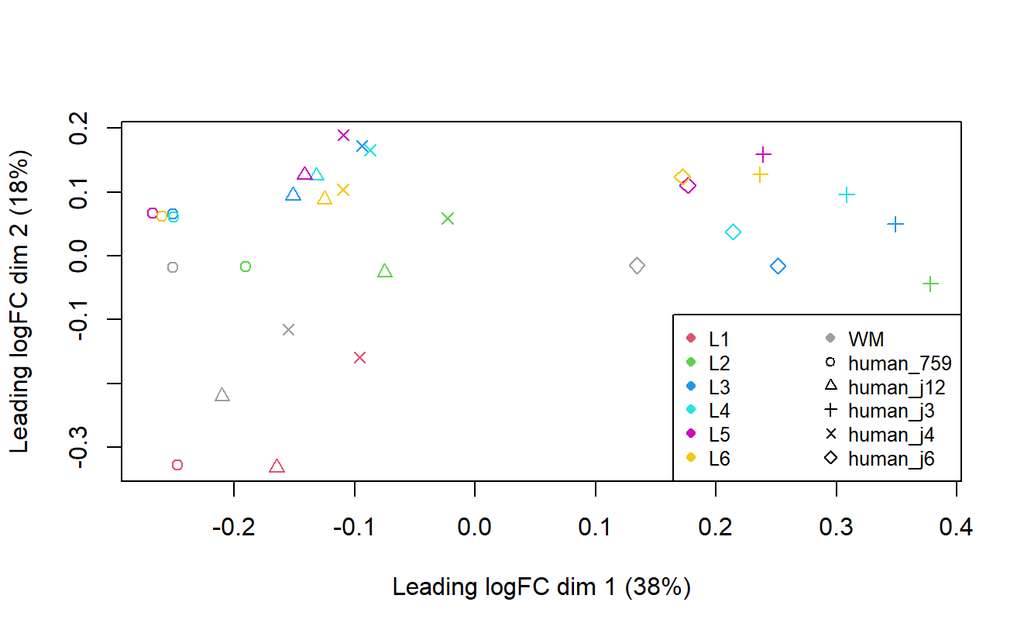

```r
layer <- as.factor(y$samples$layer)
sample_id <- y$samples$sample_id
plotMDS(y, pch=c(1:5)[sample_id], col=c(2:8)[layer])
legend("bottomright", legend=c(levels(layer), levels(sample_id)), pch=c(rep(16, 7), c(1:5)), col=c(c(2:8), rep(1, 5)), cex=0.8, ncol=2)
```

### Design matrix

```r
design <- model.matrix(~ 0 + layer + sample_id)
colnames(design) <- gsub("sample_id", "", colnames(design))
colnames(design) <- gsub("layer", "", colnames(design))
head(design)
```

```
  L1 L2 L3 L4 L5 L6 WM human_j12 human_j3 human_j4 human_j6
1  1  0  0  0  0  0  0         0        0        0        0
2  1  0  0  0  0  0  0         1        0        0        0
3  1  0  0  0  0  0  0         0        1        0        0
4  1  0  0  0  0  0  0         0        0        1        0
5  1  0  0  0  0  0  0         0        0        0        1
6  0  1  0  0  0  0  0         0        0        0        0
```

### Dispersion estimation

```r
y <- estimateDisp(y, design, robust=TRUE)
y$common.dispersion
```

```
[1] 9.765625e-05
```

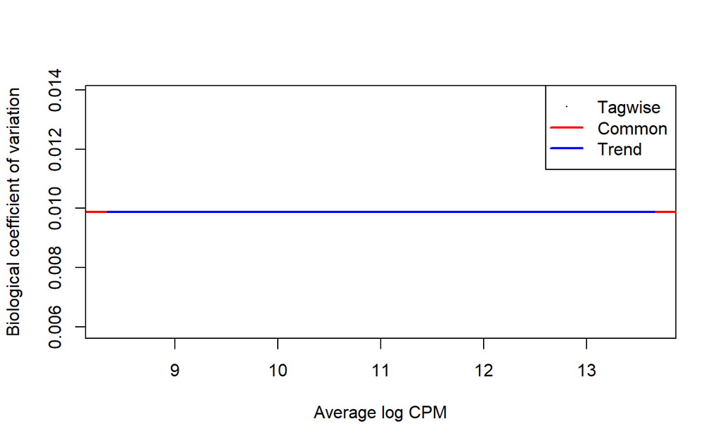

```r
plotBCV(y)
```

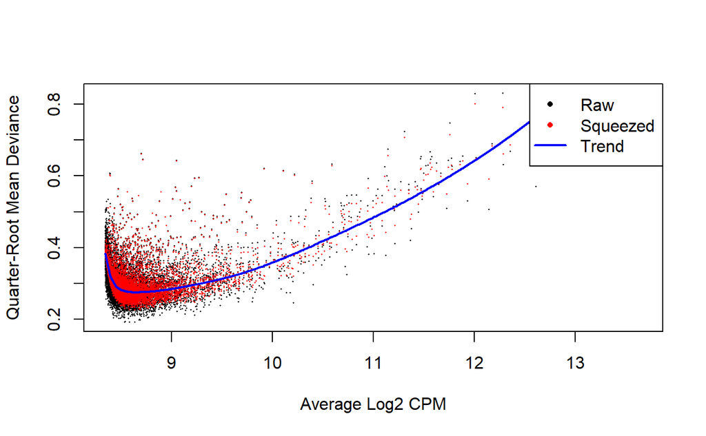

```r
fit <- glmQLFit(y, design, robust=TRUE, legacy=FALSE)
plotQLDisp(fit)
```

### Marker genes identification

Make a contrast matrix

```r
ncls <- nlevels(layer)
contr <- rbind( matrix(1 / (1 - ncls), ncls, ncls),
                matrix(0, ncol(design) - ncls, ncls)
              )
diag(contr) <- 1
rownames(contr) <- colnames(design)
colnames(contr) <- levels(layer)
contr
```

```
                  L1         L2         L3         L4         L5         L6         WM
L1         1.0000000 -0.1666667 -0.1666667 -0.1666667 -0.1666667 -0.1666667 -0.1666667
L2        -0.1666667  1.0000000 -0.1666667 -0.1666667 -0.1666667 -0.1666667 -0.1666667
L3        -0.1666667 -0.1666667  1.0000000 -0.1666667 -0.1666667 -0.1666667 -0.1666667
L4        -0.1666667 -0.1666667 -0.1666667  1.0000000 -0.1666667 -0.1666667 -0.1666667
L5        -0.1666667 -0.1666667 -0.1666667 -0.1666667  1.0000000 -0.1666667 -0.1666667
L6        -0.1666667 -0.1666667 -0.1666667 -0.1666667 -0.1666667  1.0000000 -0.1666667
WM        -0.1666667 -0.1666667 -0.1666667 -0.1666667 -0.1666667 -0.1666667  1.0000000
human_j12  0.0000000  0.0000000  0.0000000  0.0000000  0.0000000  0.0000000  0.0000000
human_j3   0.0000000  0.0000000  0.0000000  0.0000000  0.0000000  0.0000000  0.0000000
human_j4   0.0000000  0.0000000  0.0000000  0.0000000  0.0000000  0.0000000  0.0000000
human_j6   0.0000000  0.0000000  0.0000000  0.0000000  0.0000000  0.0000000  0.0000000
```

Perform quasi-likelihood F-test

```r
qlf <- list()
for (i in 1:ncls){
  qlf[[i]] <- glmQLFTest(fit, contrast=contr[,i])
  qlf[[i]]$comparison <- paste0(levels(layer)[i], '_vs_others')
}
```

The top most significant DE genes for cluster L1

```r
topTags(qlf[[1]], n=10L)
```

```
Coefficient:  L1_vs_others
```

|  | logFC | logCPM | F | PValue | FDR |
| --- | --- | --- | --- | --- | --- |
| LRIG1 | 1.553742 | 8.531236 | 303.9450 | 2.483729e-25 | 2.622818e-21 |
| ADGRG1 | 1.007869 | 8.842246 | 201.0077 | 4.218901e-22 | 2.227580e-18 |
| RELN | 3.193928 | 8.634919 | 345.7571 | 1.171133e-21 | 4.122388e-18 |
| METRN | 1.415978 | 8.690601 | 201.0725 | 1.278853e-20 | 3.376171e-17 |
| ALDOC | 1.016074 | 8.880314 | 181.5101 | 7.712699e-20 | 1.628922e-16 |
| CXCL14 | 2.617230 | 9.011470 | 262.3377 | 1.336713e-19 | 2.352614e-16 |
| GLUL | 1.071497 | 9.297614 | 228.0364 | 3.690608e-19 | 5.567545e-16 |
| MLC1 | 1.237155 | 8.578916 | 153.6090 | 1.673877e-18 | 2.209517e-15 |
| SLC1A3 | 1.338620 | 9.047061 | 205.1363 | 2.539908e-18 | 2.980159e-15 |
| AQP4 | 1.885721 | 8.940646 | 182.6338 | 4.852112e-18 | 4.834277e-15 |

```r
for (i in 1:ncls){
  write.csv(qlf[[i]]$table, file=paste0('results/humanDE/degenes_', levels(layer)[i], '.csv'))
}
```

The numbers of DE genes under each comparison

```r
dt <- lapply(lapply(qlf, decideTestsDGE), summary)
dt.all <- do.call("cbind", dt)
dt.all
```

```
       L1_vs_others L2_vs_others L3_vs_others L4_vs_others L5_vs_others L6_vs_others WM_vs_others
Down            983          793          453          487          592          391           35
NotSig         8658         8892         9298         9334         9018         9527        10367
Up              919          875          809          739          950          642          158
```

Let’s make a nice heatmap

```r
top <- 20
topMarkers <- list()
for (i in 1:ncls) {
  ord <- order(qlf[[i]]$table$PValue, decreasing=FALSE)
  up <- qlf[[i]]$table$logFC[ord] > 0
  topMarkers[[i]] <- rownames(y)[ord[up][1:top]]
}

topMarkers <- unique(unlist(topMarkers))
topMarkers
```

```
  [1] "LRIG1"    "ADGRG1"   "RELN"     "METRN"    "ALDOC"    "CXCL14"   "GLUL"     "MLC1"     "SLC1A3"
 [10] "AQP4"     "NFIB"     "PSAT1"    "VIM"      "ID4"      "PON2"     "NR2F2"    "PLPP3"    "EZR"
 [19] "CLU"      "AIF1L"    "EXOC6"    "MEIS2"    "MN1"      "SLA"      "ENC1"     "NEUROD2"  "CDC42EP3"
 [28] "PTPRO"    "EPHA3"    "MYCN"     "RIMBP2"   "DUSP4"    "CUX2"     "EIF1B"    "EBPL"     "TAFA2"
 [37] "PCDH8"    "MDGA1"    "NUP93"    "AUTS2"    "R3HDM1"   "EPHA4"    "RHOU"     "SYT4"     "CA10"
 [46] "RAC3"     "GAP43"    "CHP1"     "VOPP1"    "STXBP6"   "GNG3"     "DAAM1"    "BIN1"     "MEF2C"
 [55] "CPNE8"    "DACT1"    "NECTIN3"  "PRPS2"    "RORB"     "PIK3R1"   "SATB1"    "FOXP1"    "LDB2"
 [64] "HIVEP2"   "CXXC4"    "SSTR2"    "NELL2"    "ZFAND5"   "ST6GAL2"  "PRDM8"    "TENM1"    "KLHL4"
 [73] "CCDC85B"  "LPL"      "SYNE1"    "KCNMB4"   "TOX"      "SNAP25"   "IGSF21"   "RPRM"     "ENO2"
 [82] "TMEM14A"  "MOAP1"    "ADCY1"    "CAMKV"    "PTPRK"    "NEUROD6"  "NUDT4"    "PCDH19"   "HS3ST4"
 [91] "THY1"     "B3GALT2"  "FAM171B"  "SNCB"     "TMEM178A" "SSBP3"    "CD47"     "NPTX1"    "TBR1"
[100] "ARFGEF3"  "PPM1L"    "RASL11B"  "TENM3"    "HSPA12A"  "SV2B"     "SYT7"     "TLE4"     "NPY"
[109] "GFAP"     "ADD3"     "AHCYL1"   "SMARCA5"  "ZC3H6"    "BCAN"     "SOX8"     "MAN1A2"   "ZFP36L1"
[118] "PTPRZ1"   "QKI"      "RDX"      "PAK3"     "SDCCAG8"
```

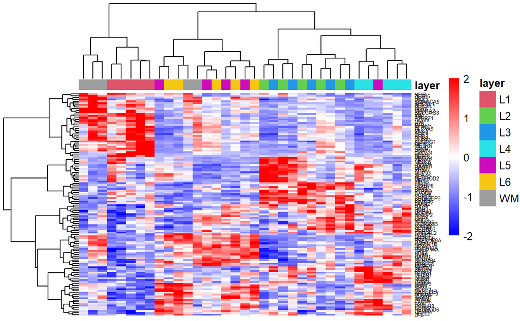

```r
lcpm <- cpm(y, log=TRUE)
annot <- data.frame(layer)
rownames(annot) <- colnames(y)
ann_colors <- list(layer=2:8)
names(ann_colors$layer) <- levels(layer)
pheatmap::pheatmap(lcpm[topMarkers,], breaks=seq(-2,2,length.out=101),
                   color=colorRampPalette(c("blue", "white", "red"))(100), scale="row",
                   ckuster_cols=TRUE, border_color="NA", fontsize_row=5,
                   treeheight_row=70, treeheight_col=70, cuttree_cols=7,
                   clustering_method="ward.D2", show_colnames=FALSE,
                   annotation_col=annot, annotation_colors=ann_colors)
```

## Chimp markers

### Prepare the data

```r
ann <- annotation[annotation$condition == 'chimp',]
head(ann)
```

|  | layer | sample_id | psbulk_n_cells | psbulk_counts | condition | layer_c |
| --- | --- | --- | --- | --- | --- | --- |
| chimp_11454_L1 | L1 | chimp_11454 | 202 | 360976 | chimp | 1 |
| chimp_13309_L1 | L1 | chimp_13309 | 201 | 313326 | chimp | 1 |
| chimp_j8_L1 | L1 | chimp_j8 | 398 | 862771 | chimp | 1 |
| chimp_11454_L2 | L2 | chimp_11454 | 167 | 504292 | chimp | 2 |
| chimp_13309_L2 | L2 | chimp_13309 | 136 | 412983 | chimp | 2 |
| chimp_j8_L2 | L2 | chimp_j8 | 201 | 1219488 | chimp | 2 |

```r
expr <- expression[, row.names(ann)]
head(expr)
```

|  | chimp_11454_L1 | chimp_13309_L1 | chimp_j8_L1 | chimp_11454_L2 | chimp_13309_L2 | chimp_j8_L2 | chimp_11454_L3 | chimp_13309_L3 | chimp_j11_L3 | chimp_j8_L3 | chimp_11454_L4 | chimp_13309_L4 | chimp_j11_L4 | chimp_j8_L4 | chimp_11454_L5 | chimp_13309_L5 | chimp_j11_L5 | chimp_j8_L5 | chimp_11454_L6 | chimp_13309_L6 | chimp_j11_L6 | chimp_j8_L6 | chimp_11454_WM | chimp_13309_WM | chimp_j11_WM | chimp_j8_WM |
| --- | --- | --- | --- | --- | --- | --- | --- | --- | --- | --- | --- | --- | --- | --- | --- | --- | --- | --- | --- | --- | --- | --- | --- | --- | --- | --- |
| A1BG | 0.02475247 | 0.004975124 | 0.032663316 | 0.02994012 | 0.007352941 | 0.06965174 | 0.076167080 | 0.049822062 | 0.1639344 | 0.142091160 | 0.079470200 | 0.0390625 | 0.1368421 | 0.174807190 | 0.0431566 | 0.02334630 | 0.060449050 | 0.067524110 | 0.0191304350 | 0.008417509 | 0.0200160130 | 0.019512195 | 0.000000000 | 0.005988024 | 0.0108271980 | 0.01260504 |
| A1CF | 0.00000000 | 0.000000000 | 0.000000000 | 0.00000000 | 0.000000000 | 0.00000000 | 0.000000000 | 0.000000000 | 0.0000000 | 0.001340483 | 0.000000000 | 0.0000000 | 0.0000000 | 0.000000000 | 0.0000000 | 0.00000000 | 0.000000000 | 0.000000000 | 0.0000000000 | 0.000000000 | 0.0000000000 | 0.000000000 | 0.000000000 | 0.000000000 | 0.0000000000 | 0.00000000 |
| A2ML1 | 0.00000000 | 0.000000000 | 0.007537689 | 0.00000000 | 0.007352941 | 0.00000000 | 0.002457002 | 0.001779359 | 0.0000000 | 0.001340483 | 0.003311258 | 0.0078125 | 0.0000000 | 0.002570694 | 0.0000000 | 0.00000000 | 0.000000000 | 0.001607717 | 0.0008695652 | 0.000000000 | 0.0008006405 | 0.004878049 | 0.009174312 | 0.001497006 | 0.0008661759 | 0.00000000 |
| A4GALT | 0.00000000 | 0.000000000 | 0.000000000 | 0.00000000 | 0.000000000 | 0.00000000 | 0.000000000 | 0.000000000 | 0.0000000 | 0.000000000 | 0.000000000 | 0.0000000 | 0.0000000 | 0.000000000 | 0.0000000 | 0.00000000 | 0.001727116 | 0.000000000 | 0.0000000000 | 0.000000000 | 0.0000000000 | 0.000000000 | 0.000000000 | 0.000000000 | 0.0000000000 | 0.00000000 |
| AAAS | 0.05940594 | 0.019900497 | 0.050251257 | 0.06586827 | 0.044117650 | 0.12437811 | 0.052825550 | 0.088967970 | 0.1202186 | 0.150134040 | 0.079470200 | 0.1132812 | 0.1684211 | 0.146529570 | 0.0702836 | 0.05836576 | 0.110535406 | 0.083601290 | 0.0434782600 | 0.102693600 | 0.0264211370 | 0.053658538 | 0.055045873 | 0.022455090 | 0.0246860100 | 0.02801121 |
| AACS | 0.13861386 | 0.099502490 | 0.128140700 | 0.25149700 | 0.095588240 | 0.39303482 | 0.330466840 | 0.382562280 | 0.3879781 | 0.430294900 | 0.324503300 | 0.3984375 | 0.5789474 | 0.609254500 | 0.3242910 | 0.37743190 | 0.385146800 | 0.541800600 | 0.2060869600 | 0.343434330 | 0.1489191400 | 0.295121940 | 0.220183490 | 0.078592815 | 0.0662624540 | 0.08263306 |

```r
NA
```

Factor the data

```r
ann$layer <- factor(ann$layer)
ann$sample_id <- factor(ann$sample_id)
head(ann)
```

|  | layer | sample_id | psbulk_n_cells | psbulk_counts | condition | layer_c |
| --- | --- | --- | --- | --- | --- | --- |
| chimp_11454_L1 | L1 | chimp_11454 | 202 | 360976 | chimp | 1 |
| chimp_13309_L1 | L1 | chimp_13309 | 201 | 313326 | chimp | 1 |
| chimp_j8_L1 | L1 | chimp_j8 | 398 | 862771 | chimp | 1 |
| chimp_11454_L2 | L2 | chimp_11454 | 167 | 504292 | chimp | 2 |
| chimp_13309_L2 | L2 | chimp_13309 | 136 | 412983 | chimp | 2 |
| chimp_j8_L2 | L2 | chimp_j8 | 201 | 1219488 | chimp | 2 |

```r
y <- DGEList(counts=expr, samples=ann)
y
```

```
An object of class "DGEList"
$counts
       chimp_11454_L1 chimp_13309_L1 chimp_j8_L1 chimp_11454_L2 chimp_13309_L2 chimp_j8_L2 chimp_11454_L3
A1BG       0.02475247    0.004975124 0.032663316     0.02994012    0.007352941  0.06965174    0.076167080
A1CF       0.00000000    0.000000000 0.000000000     0.00000000    0.000000000  0.00000000    0.000000000
A2ML1      0.00000000    0.000000000 0.007537689     0.00000000    0.007352941  0.00000000    0.002457002
A4GALT     0.00000000    0.000000000 0.000000000     0.00000000    0.000000000  0.00000000    0.000000000
AAAS       0.05940594    0.019900497 0.050251257     0.06586827    0.044117650  0.12437811    0.052825550
       chimp_13309_L3 chimp_j11_L3 chimp_j8_L3 chimp_11454_L4 chimp_13309_L4 chimp_j11_L4 chimp_j8_L4
A1BG      0.049822062    0.1639344 0.142091160    0.079470200      0.0390625    0.1368421 0.174807190
A1CF      0.000000000    0.0000000 0.001340483    0.000000000      0.0000000    0.0000000 0.000000000
A2ML1     0.001779359    0.0000000 0.001340483    0.003311258      0.0078125    0.0000000 0.002570694
A4GALT    0.000000000    0.0000000 0.000000000    0.000000000      0.0000000    0.0000000 0.000000000
AAAS      0.088967970    0.1202186 0.150134040    0.079470200      0.1132812    0.1684211 0.146529570
       chimp_11454_L5 chimp_13309_L5 chimp_j11_L5 chimp_j8_L5 chimp_11454_L6 chimp_13309_L6 chimp_j11_L6
A1BG        0.0431566     0.02334630  0.060449050 0.067524110   0.0191304350    0.008417509 0.0200160130
A1CF        0.0000000     0.00000000  0.000000000 0.000000000   0.0000000000    0.000000000 0.0000000000
A2ML1       0.0000000     0.00000000  0.000000000 0.001607717   0.0008695652    0.000000000 0.0008006405
A4GALT      0.0000000     0.00000000  0.001727116 0.000000000   0.0000000000    0.000000000 0.0000000000
AAAS        0.0702836     0.05836576  0.110535406 0.083601290   0.0434782600    0.102693600 0.0264211370
       chimp_j8_L6 chimp_11454_WM chimp_13309_WM chimp_j11_WM chimp_j8_WM
A1BG   0.019512195    0.000000000    0.005988024 0.0108271980  0.01260504
A1CF   0.000000000    0.000000000    0.000000000 0.0000000000  0.00000000
A2ML1  0.004878049    0.009174312    0.001497006 0.0008661759  0.00000000
A4GALT 0.000000000    0.000000000    0.000000000 0.0000000000  0.00000000
AAAS   0.053658538    0.055045873    0.022455090 0.0246860100  0.02801121
14958 more rows ...

$samples
```

|  | group | lib.size | norm.factors | layer | sample_id | psbulk_n_cells | psbulk_counts | condition | layer_c |
| --- | --- | --- | --- | --- | --- | --- | --- | --- | --- |
| chimp_11454_L1 | 1 | 1787.010 | 1 | L1 | chimp_11454 | 202 | 360976 | chimp | 1 |
| chimp_13309_L1 | 1 | 1558.836 | 1 | L1 | chimp_13309 | 201 | 313326 | chimp | 1 |
| chimp_j8_L1 | 1 | 2167.766 | 1 | L1 | chimp_j8 | 398 | 862771 | chimp | 1 |
| chimp_11454_L2 | 1 | 3019.713 | 1 | L2 | chimp_11454 | 167 | 504292 | chimp | 2 |
| chimp_13309_L2 | 1 | 3036.640 | 1 | L2 | chimp_13309 | 136 | 412983 | chimp | 2 |

```
21 more rows ...
```

### Filtering and normalization

Let’s check a summary table

```r
summary(ann)
```

```
 layer        sample_id psbulk_n_cells   psbulk_counts      condition            layer_c
 L1:3   chimp_11454:7   Min.   : 109.0   Min.   : 209589   Length:26          Min.   :1.000
 L2:3   chimp_13309:7   1st Qu.: 201.2   1st Qu.: 875476   Class :character   1st Qu.:3.000
 L3:4   chimp_j11  :5   Median : 404.0   Median :1456625   Mode  :character   Median :4.000
 L4:4   chimp_j8   :7   Mean   : 594.2   Mean   :1803551                      Mean   :4.192
 L5:4                   3rd Qu.: 794.8   3rd Qu.:2254674                      3rd Qu.:6.000
 L6:4                   Max.   :2309.0   Max.   :6422786                      Max.   :7.000
 WM:4
```

Now filter out lowly expressed genes

```r
keep.genes <- filterByExpr(y, group=y$samples$layer, min.count=0.01, min.total.count=1)
table(keep.genes)
```

```
keep.genes
FALSE  TRUE
 7422  7541
```

```r
y <- y[keep.genes, , keep=FALSE]
```

TMM normalization

```r
y <- normLibSizes(y)
head(y$samples, n=10L)
```

|  | group | lib.size | norm.factors | layer | sample_id | psbulk_n_cells | psbulk_counts | condition | layer_c |
| --- | --- | --- | --- | --- | --- | --- | --- | --- | --- |
| chimp_11454_L1 | 1 | 1743.797 | 0.9939323 | L1 | chimp_11454 | 202 | 360976 | chimp | 1 |
| chimp_13309_L1 | 1 | 1528.294 | 1.0291134 | L1 | chimp_13309 | 201 | 313326 | chimp | 1 |
| chimp_j8_L1 | 1 | 2126.560 | 1.0270244 | L1 | chimp_j8 | 398 | 862771 | chimp | 1 |
| chimp_11454_L2 | 1 | 2972.018 | 1.0156343 | L2 | chimp_11454 | 167 | 504292 | chimp | 2 |
| chimp_13309_L2 | 1 | 2989.787 | 1.0273095 | L2 | chimp_13309 | 136 | 412983 | chimp | 2 |
| chimp_j8_L2 | 1 | 5987.303 | 0.9966814 | L2 | chimp_j8 | 201 | 1219488 | chimp | 2 |
| chimp_11454_L3 | 1 | 3147.627 | 1.0157256 | L3 | chimp_11454 | 814 | 2602051 | chimp | 3 |
| chimp_13309_L3 | 1 | 5638.154 | 1.0106771 | L3 | chimp_13309 | 1124 | 6422786 | chimp | 3 |
| chimp_j11_L3 | 1 | 4418.738 | 0.9178654 | L3 | chimp_j11 | 183 | 821411 | chimp | 3 |
| chimp_j8_L3 | 1 | 6891.213 | 0.9905978 | L3 | chimp_j8 | 746 | 5205665 | chimp | 3 |

```r
summary(y$samples$norm.factors)
```

```
   Min. 1st Qu.  Median    Mean 3rd Qu.    Max.
 0.9112  0.9939  1.0118  1.0006  1.0230  1.0529
```

### Data exploration

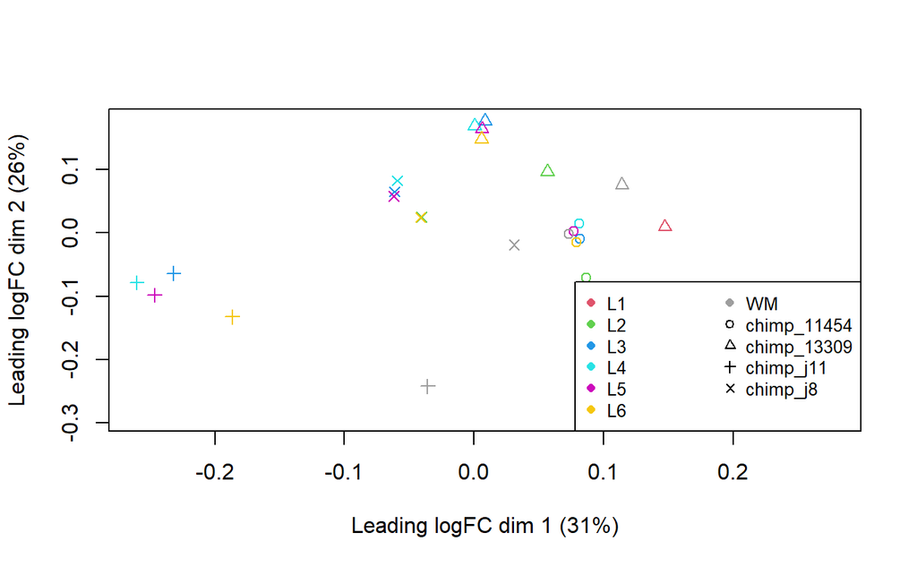

```r
layer <- as.factor(y$samples$layer)
sample_id <- y$samples$sample_id
plotMDS(y, pch=c(1:5)[sample_id], col=c(2:8)[layer])
legend("bottomright", legend=c(levels(layer), levels(sample_id)), pch=c(rep(16, 7), c(1:5)), col=c(c(2:8), rep(1, 5)), cex=0.8, ncol=2)
```

### Design matrix

```r
design <- model.matrix(~ 0 + layer + sample_id)
colnames(design) <- gsub("sample_id", "", colnames(design))
colnames(design) <- gsub("layer", "", colnames(design))
head(design)
```

```
  L1 L2 L3 L4 L5 L6 WM chimp_13309 chimp_j11 chimp_j8
1  1  0  0  0  0  0  0           0         0        0
2  1  0  0  0  0  0  0           1         0        0
3  1  0  0  0  0  0  0           0         0        1
4  0  1  0  0  0  0  0           0         0        0
5  0  1  0  0  0  0  0           1         0        0
6  0  1  0  0  0  0  0           0         0        1
```

### Dispersion estimation

```r
y <- estimateDisp(y, design, robust=TRUE)
y$common.dispersion
```

```
[1] 9.765625e-05
```

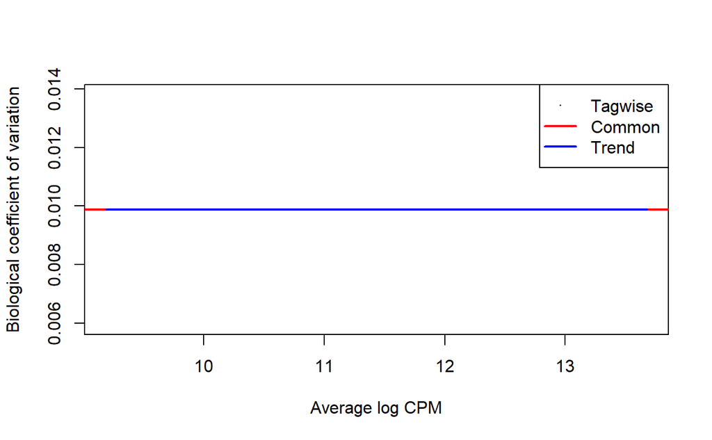

```r
plotBCV(y)
```

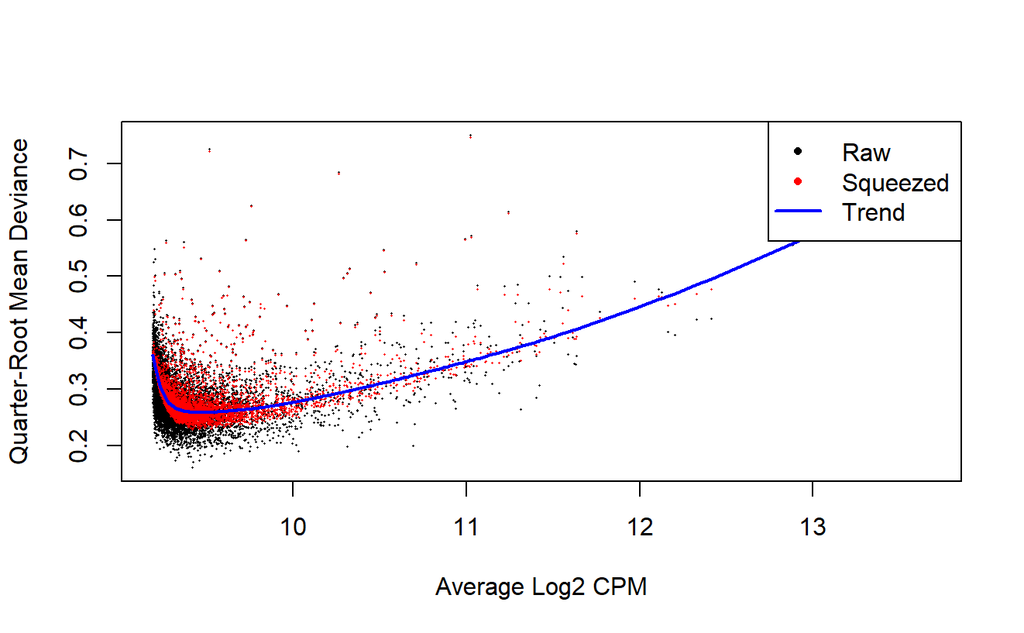

```r
fit <- glmQLFit(y, design, robust=TRUE, legacy=FALSE)
plotQLDisp(fit)
```

### Marker genes identification

Make a contrast matrix

```r
ncls <- nlevels(layer)
contr <- rbind( matrix(1 / (1 - ncls), ncls, ncls),
                matrix(0, ncol(design) - ncls, ncls)
              )
diag(contr) <- 1
rownames(contr) <- colnames(design)
colnames(contr) <- levels(layer)
contr
```

```
                    L1         L2         L3         L4         L5         L6         WM
L1           1.0000000 -0.1666667 -0.1666667 -0.1666667 -0.1666667 -0.1666667 -0.1666667
L2          -0.1666667  1.0000000 -0.1666667 -0.1666667 -0.1666667 -0.1666667 -0.1666667
L3          -0.1666667 -0.1666667  1.0000000 -0.1666667 -0.1666667 -0.1666667 -0.1666667
L4          -0.1666667 -0.1666667 -0.1666667  1.0000000 -0.1666667 -0.1666667 -0.1666667
L5          -0.1666667 -0.1666667 -0.1666667 -0.1666667  1.0000000 -0.1666667 -0.1666667
L6          -0.1666667 -0.1666667 -0.1666667 -0.1666667 -0.1666667  1.0000000 -0.1666667
WM          -0.1666667 -0.1666667 -0.1666667 -0.1666667 -0.1666667 -0.1666667  1.0000000
chimp_13309  0.0000000  0.0000000  0.0000000  0.0000000  0.0000000  0.0000000  0.0000000
chimp_j11    0.0000000  0.0000000  0.0000000  0.0000000  0.0000000  0.0000000  0.0000000
chimp_j8     0.0000000  0.0000000  0.0000000  0.0000000  0.0000000  0.0000000  0.0000000
```

Perform quasi-likelihood F-test

```r
qlf <- list()
for (i in 1:ncls){
  qlf[[i]] <- glmQLFTest(fit, contrast=contr[,i])
  qlf[[i]]$comparison <- paste0(levels(layer)[i], '_vs_others')
}
```

The top most significant DE genes for cluster L1

```r
topTags(qlf[[1]], n=10L)
```

```
Coefficient:  L1_vs_others
```

|  | logFC | logCPM | F | PValue | FDR |
| --- | --- | --- | --- | --- | --- |
| SNORC | 1.6583359 | 9.427728 | 440.3377 | 1.094636e-30 | 8.254646e-27 |
| CLEC3B | 1.2234351 | 9.367450 | 200.2941 | 1.219407e-21 | 4.597775e-18 |
| ADIRF | 1.2038712 | 9.326888 | 177.8789 | 1.145101e-19 | 2.878402e-16 |
| VIM | 2.2439779 | 9.734862 | 363.1811 | 2.188362e-19 | 4.125610e-16 |
| COL1A1 | 2.4778045 | 9.301591 | 568.4114 | 4.040026e-19 | 5.366231e-16 |
| COL18A1 | 1.2364060 | 9.300164 | 184.5132 | 4.269644e-19 | 5.366231e-16 |
| EEF1D | 0.8298058 | 9.463327 | 133.9070 | 3.569905e-18 | 3.845808e-15 |
| NCAN | 0.6932442 | 10.078920 | 148.7314 | 4.892973e-18 | 4.612239e-15 |
| COL3A1 | 2.5603664 | 9.318766 | 551.1152 | 4.458698e-17 | 3.735894e-14 |
| AIF1L | 1.1650831 | 9.322540 | 131.3051 | 4.360366e-16 | 3.288152e-13 |

```r
for (i in 1:ncls){
  write.csv(qlf[[i]]$table, file=paste0('results/chimpDE/degenes_', levels(layer)[i], '.csv'))
}
```

The numbers of DE genes under each comparison

```r
dt <- lapply(lapply(qlf, decideTestsDGE), summary)
dt.all <- do.call("cbind", dt)
dt.all
```

```
       L1_vs_others L2_vs_others L3_vs_others L4_vs_others L5_vs_others L6_vs_others WM_vs_others
Down            477          152          156          191           77           44           11
NotSig         6490         7127         7013         6949         7255         7394         7497
Up              574          262          372          401          209          103           33
```

Let’s make a nice heatmap

```r
top <- 20
topMarkers <- list()
for (i in 1:ncls) {
  ord <- order(qlf[[i]]$table$PValue, decreasing=FALSE)
  up <- qlf[[i]]$table$logFC[ord] > 0
  topMarkers[[i]] <- rownames(y)[ord[up][1:top]]
}

topMarkers <- unique(unlist(topMarkers))
topMarkers
```

```
  [1] "SNORC"    "CLEC3B"   "ADIRF"    "VIM"      "COL1A1"   "COL18A1"  "EEF1D"    "NCAN"     "COL3A1"
 [10] "AIF1L"    "COL4A1"   "TPT1"     "FABP7"    "ALDOC"    "LMO2"     "ANXA5"    "FBLN1"    "TAGLN"
 [19] "COL4A2"   "TIMP1"    "MEIS2"    "MN1"      "RNF2"     "PCDH8"    "RGMB"     "TMOD1"    "IGFBP2"
 [28] "SRM"      "PBX1"     "AP1S2"    "DACT1"    "LIMCH1"   "SYNPR"    "NEO1"     "LRRC8B"   "VSTM2A"
 [37] "CCK"      "FRZB"     "MARCKSL1" "NETO2"    "CHN1"     "PTPRF"    "B4GALT2"  "PCSK2"    "PPP3CA"
 [46] "NOL4"     "ACTR3B"   "SPATS2L"  "FGF13"    "DUSP23"   "STYK1"    "CA10"     "TM2D3"    "LANCL2"
 [55] "PAK6"     "FBXW7"    "CHP1"     "NPTN"     "HIVEP2"   "PTPRN"    "SLC39A10" "NUDT4"    "NRN1"
 [64] "HSPH1"    "NWD2"     "LDB2"     "CHGB"     "STARD3NL" "GABRA5"   "PPP2R2C"  "SLC17A7"  "MAPRE2"
 [73] "SNCG"     "GLYR1"    "WDR47"    "NELL2"    "SNAP25"   "KLHL1"    "CRYM"     "PFKP"     "UBE2QL1"
 [82] "TTC9B"    "SATB1"    "TAC1"     "VAT1L"    "CMAS"     "PLCB1"    "SYNGR3"   "GOT1"     "DNM1"
 [91] "CNIH3"    "KCNC2"    "IGSF21"   "TLE4"     "ATP2B4"   "NTNG2"    "NCALD"    "CPLX3"    "UGP2"
[100] "RASGRP1"  "NPTX1"    "PCDH17"   "TBR1"     "CDH2"     "SEMA3E"   "SLC25A22" "RALYL"    "SLIT1"
[109] "CALY"     "PRDX1"    "GFAP"     "GABRG1"   "NPY"      "SIRT2"    "NUAK1"    "PLP1"     "AHCYL1"
[118] "HEPACAM"  "SMOC1"    "ALDH1A1"
```

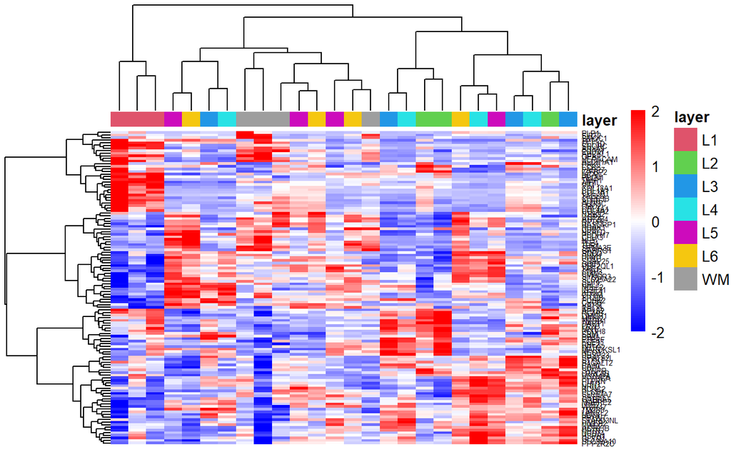

```r
lcpm <- cpm(y, log=TRUE)
annot <- data.frame(layer)
rownames(annot) <- colnames(y)
ann_colors <- list(layer=2:8)
names(ann_colors$layer) <- levels(layer)
pheatmap::pheatmap(lcpm[topMarkers,], breaks=seq(-2,2,length.out=101),
                   color=colorRampPalette(c("blue", "white", "red"))(100), scale="row",
                   ckuster_cols=TRUE, border_color="NA", fontsize_row=5,
                   treeheight_row=70, treeheight_col=70, cuttree_cols=7,
                   clustering_method="ward.D2", show_colnames=FALSE,
                   annotation_col=annot, annotation_colors=ann_colors)
```

## Macaque markers

### Prepare the data

```r
annotation
```

|  | layer | sample_id | psbulk_n_cells | psbulk_counts | condition | layer_c |
| --- | --- | --- | --- | --- | --- | --- |
| chimp_11454_L1 | L1 | chimp_11454 | 202 | 360976 | chimp | 1 |
| chimp_13309_L1 | L1 | chimp_13309 | 201 | 313326 | chimp | 1 |
| chimp_j8_L1 | L1 | chimp_j8 | 398 | 862771 | chimp | 1 |
| human_759_L1 | L1 | human_759 | 500 | 961453 | human | 1 |
| human_j12_L1 | L1 | human_j12 | 331 | 827957 | human | 1 |
| human_j3_L1 | L1 | human_j3 | 110 | 378096 | human | 1 |
| human_j4_L1 | L1 | human_j4 | 238 | 770218 | human | 1 |
| human_j6_L1 | L1 | human_j6 | 134 | 255642 | human | 1 |
| macaque_0701_L1 | L1 | macaque_0701 | 286 | 1152346 | macaque | 1 |
| macaque_0703_L1 | L1 | macaque_0703 | 196 | 472065 | macaque | 1 |

[output cut: 79 more lines]

```r
ann <- annotation[annotation$condition == 'macaque',]
head(ann)
```

|  | layer | sample_id | psbulk_n_cells | psbulk_counts | condition | layer_c |
| --- | --- | --- | --- | --- | --- | --- |
| macaque_0701_L1 | L1 | macaque_0701 | 286 | 1152346 | macaque | 1 |
| macaque_0703_L1 | L1 | macaque_0703 | 196 | 472065 | macaque | 1 |
| macaque_0704_L1 | L1 | macaque_0704 | 285 | 528036 | macaque | 1 |
| macaque_nb0904_L1 | L1 | macaque_nb0904 | 635 | 716506 | macaque | 1 |
| macaque_0701_L2 | L2 | macaque_0701 | 230 | 2282690 | macaque | 2 |
| macaque_0703_L2 | L2 | macaque_0703 | 398 | 2592926 | macaque | 2 |

```r
expr <- expression[, row.names(ann)]
head(expr)
```

|  | macaque_0701_L1 | macaque_0703_L1 | macaque_0704_L1 | macaque_nb0904_L1 | macaque_0701_L2 | macaque_0703_L2 | macaque_0704_L2 | macaque_nb0904_L2 | macaque_0701_L3 | macaque_0703_L3 | macaque_0704_L3 | macaque_nb0904_L3 | macaque_0701_L4 | macaque_0703_L4 | macaque_0704_L4 | macaque_nb0904_L4 | macaque_0701_L5 | macaque_0703_L5 | macaque_0704_L5 | macaque_nb0904_L5 | macaque_0701_L6 | macaque_0703_L6 | macaque_0704_L6 | macaque_nb0904_L6 | macaque_0701_WM | macaque_0703_WM | macaque_0704_WM | macaque_nb0904_WM |
| --- | --- | --- | --- | --- | --- | --- | --- | --- | --- | --- | --- | --- | --- | --- | --- | --- | --- | --- | --- | --- | --- | --- | --- | --- | --- | --- | --- | --- |
| A1BG | 0.003496503 | 0.00000000 | 0.003508772 | 0.000000000 | 0.008695652 | 0.017587940 | 0.007874016 | 0.02127659 | 0.00754717 | 0.003878976 | 0.0065885796 | 0.002838221 | 0.009505703 | 0.008196721 | 0.005199307 | 0.0000000 | 0.00204499 | 0.009661836 | 0.004357298 | 0.004571429 | 0.000000000 | 0.007633588 | 0.006514658 | 0.001432665 | 0.00000000 | 0.00000000 | 0.00000000 | 0.01136364 |
| A1CF | 0.000000000 | 0.00000000 | 0.000000000 | 0.000000000 | 0.000000000 | 0.000000000 | 0.000000000 | 0.00000000 | 0.00000000 | 0.000000000 | 0.0007320644 | 0.000000000 | 0.000000000 | 0.000000000 | 0.000000000 | 0.0000000 | 0.00000000 | 0.000000000 | 0.000000000 | 0.001142857 | 0.000000000 | 0.000000000 | 0.000000000 | 0.000000000 | 0.00000000 | 0.00000000 | 0.00000000 | 0.00000000 |
| A2ML1 | 0.000000000 | 0.00000000 | 0.000000000 | 0.000000000 | 0.000000000 | 0.000000000 | 0.000000000 | 0.00000000 | 0.00000000 | 0.000000000 | 0.0000000000 | 0.000000000 | 0.000000000 | 0.000000000 | 0.000000000 | 0.0000000 | 0.00000000 | 0.001610306 | 0.000000000 | 0.000000000 | 0.000000000 | 0.000000000 | 0.000000000 | 0.000000000 | 0.00000000 | 0.00000000 | 0.00000000 | 0.00000000 |
| A4GALT | 0.034965035 | 0.01020408 | 0.010526316 | 0.009448819 | 0.030434782 | 0.007537689 | 0.003937008 | 0.01063830 | 0.02389937 | 0.009309542 | 0.0043923864 | 0.004730369 | 0.009505703 | 0.002732240 | 0.005199307 | 0.0000000 | 0.01022495 | 0.003220612 | 0.002178649 | 0.006857143 | 0.009966778 | 0.007633588 | 0.000000000 | 0.001432665 | 0.03703704 | 0.01904762 | 0.02597403 | 0.01136364 |
| AAAS | 0.066433564 | 0.03571429 | 0.017543860 | 0.011023622 | 0.100000000 | 0.062814070 | 0.031496063 | 0.01418440 | 0.09182390 | 0.070597365 | 0.0768667600 | 0.017029328 | 0.093155890 | 0.092896180 | 0.086655110 | 0.0245614 | 0.05521472 | 0.086956520 | 0.074074075 | 0.016000000 | 0.049833886 | 0.051526718 | 0.042345278 | 0.012893983 | 0.01851852 | 0.04285714 | 0.02597403 | 0.00000000 |
| AACS | 0.545454560 | 0.30102040 | 0.217543860 | 0.165354330 | 1.517391300 | 0.917085400 | 0.673228300 | 0.29432625 | 1.82893090 | 1.287044200 | 1.0387994000 | 0.361400200 | 1.819391600 | 1.229508200 | 1.079722800 | 0.3929824 | 1.26380370 | 1.190016200 | 1.126361600 | 0.406857130 | 0.318936880 | 0.603053450 | 0.537459250 | 0.257879640 | 0.20370370 | 0.29047620 | 0.33766234 | 0.17045455 |

```r
NA
```

Factor the data

```r
ann$layer <- factor(ann$layer)
ann$sample_id <- factor(ann$sample_id)
head(ann)
```

|  | layer | sample_id | psbulk_n_cells | psbulk_counts | condition | layer_c |
| --- | --- | --- | --- | --- | --- | --- |
| macaque_0701_L1 | L1 | macaque_0701 | 286 | 1152346 | macaque | 1 |
| macaque_0703_L1 | L1 | macaque_0703 | 196 | 472065 | macaque | 1 |
| macaque_0704_L1 | L1 | macaque_0704 | 285 | 528036 | macaque | 1 |
| macaque_nb0904_L1 | L1 | macaque_nb0904 | 635 | 716506 | macaque | 1 |
| macaque_0701_L2 | L2 | macaque_0701 | 230 | 2282690 | macaque | 2 |
| macaque_0703_L2 | L2 | macaque_0703 | 398 | 2592926 | macaque | 2 |

```r
y <- DGEList(counts=expr, samples=ann)
y
```

```
An object of class "DGEList"
$counts
       macaque_0701_L1 macaque_0703_L1 macaque_0704_L1 macaque_nb0904_L1 macaque_0701_L2 macaque_0703_L2
A1BG       0.003496503      0.00000000     0.003508772       0.000000000     0.008695652     0.017587940
A1CF       0.000000000      0.00000000     0.000000000       0.000000000     0.000000000     0.000000000
A2ML1      0.000000000      0.00000000     0.000000000       0.000000000     0.000000000     0.000000000
A4GALT     0.034965035      0.01020408     0.010526316       0.009448819     0.030434782     0.007537689
AAAS       0.066433564      0.03571429     0.017543860       0.011023622     0.100000000     0.062814070
       macaque_0704_L2 macaque_nb0904_L2 macaque_0701_L3 macaque_0703_L3 macaque_0704_L3 macaque_nb0904_L3
A1BG       0.007874016        0.02127659      0.00754717     0.003878976    0.0065885796       0.002838221
A1CF       0.000000000        0.00000000      0.00000000     0.000000000    0.0007320644       0.000000000
A2ML1      0.000000000        0.00000000      0.00000000     0.000000000    0.0000000000       0.000000000
A4GALT     0.003937008        0.01063830      0.02389937     0.009309542    0.0043923864       0.004730369
AAAS       0.031496063        0.01418440      0.09182390     0.070597365    0.0768667600       0.017029328
       macaque_0701_L4 macaque_0703_L4 macaque_0704_L4 macaque_nb0904_L4 macaque_0701_L5 macaque_0703_L5
A1BG       0.009505703     0.008196721     0.005199307         0.0000000      0.00204499     0.009661836
A1CF       0.000000000     0.000000000     0.000000000         0.0000000      0.00000000     0.000000000
A2ML1      0.000000000     0.000000000     0.000000000         0.0000000      0.00000000     0.001610306
A4GALT     0.009505703     0.002732240     0.005199307         0.0000000      0.01022495     0.003220612
AAAS       0.093155890     0.092896180     0.086655110         0.0245614      0.05521472     0.086956520
       macaque_0704_L5 macaque_nb0904_L5 macaque_0701_L6 macaque_0703_L6 macaque_0704_L6 macaque_nb0904_L6
A1BG       0.004357298       0.004571429     0.000000000     0.007633588     0.006514658       0.001432665
A1CF       0.000000000       0.001142857     0.000000000     0.000000000     0.000000000       0.000000000
A2ML1      0.000000000       0.000000000     0.000000000     0.000000000     0.000000000       0.000000000
A4GALT     0.002178649       0.006857143     0.009966778     0.007633588     0.000000000       0.001432665
AAAS       0.074074075       0.016000000     0.049833886     0.051526718     0.042345278       0.012893983
       macaque_0701_WM macaque_0703_WM macaque_0704_WM macaque_nb0904_WM
A1BG        0.00000000      0.00000000      0.00000000        0.01136364
A1CF        0.00000000      0.00000000      0.00000000        0.00000000
A2ML1       0.00000000      0.00000000      0.00000000        0.00000000
A4GALT      0.03703704      0.01904762      0.02597403        0.01136364
AAAS        0.01851852      0.04285714      0.02597403        0.00000000
14958 more rows ...

$samples
```

|  | group | lib.size | norm.factors | layer | sample_id | psbulk_n_cells | psbulk_counts | condition | layer_c |
| --- | --- | --- | --- | --- | --- | --- | --- | --- | --- |
| macaque_0701_L1 | 1 | 4029.182 | 1 | L1 | macaque_0701 | 286 | 1152346 | macaque | 1 |
| macaque_0703_L1 | 1 | 2408.495 | 1 | L1 | macaque_0703 | 196 | 472065 | macaque | 1 |
| macaque_0704_L1 | 1 | 1852.758 | 1 | L1 | macaque_0704 | 285 | 528036 | macaque | 1 |
| macaque_nb0904_L1 | 1 | 1128.356 | 1 | L1 | macaque_nb0904 | 635 | 716506 | macaque | 1 |
| macaque_0701_L2 | 1 | 9924.739 | 1 | L2 | macaque_0701 | 230 | 2282690 | macaque | 2 |

```
23 more rows ...
```

### Filtering and normalization

Let’s check a summary table

```r
summary(ann)
```

```
 layer           sample_id psbulk_n_cells   psbulk_counts      condition            layer_c
 L1:4   macaque_0701  :7   Min.   :  54.0   Min.   :  82690   Length:28          Min.   :1
 L2:4   macaque_0703  :7   1st Qu.: 275.0   1st Qu.: 587210   Class :character   1st Qu.:2
 L3:4   macaque_0704  :7   Median : 382.0   Median :1447338   Mode  :character   Median :4
 L4:4   macaque_nb0904:7   Mean   : 483.2   Mean   :2362762                      Mean   :4
 L5:4                      3rd Qu.: 624.5   3rd Qu.:2860663                      3rd Qu.:6
 L6:4                      Max.   :1366.0   Max.   :9473501                      Max.   :7
 WM:4
```

Now filter out lowly expressed genes

```r
keep.genes <- filterByExpr(y, group=y$samples$layer, min.count=0.01, min.total.count=1)
table(keep.genes)
```

```
keep.genes
FALSE  TRUE
 7149  7814
```

```r
y <- y[keep.genes, , keep=FALSE]
```

TMM normalization

```r
y <- normLibSizes(y)
head(y$samples, n=10L)
```

|  | group | lib.size | norm.factors | layer | sample_id | psbulk_n_cells | psbulk_counts | condition | layer_c |
| --- | --- | --- | --- | --- | --- | --- | --- | --- | --- |
| macaque_0701_L1 | 1 | 3971.899 | 1.0230194 | L1 | macaque_0701 | 286 | 1152346 | macaque | 1 |
| macaque_0703_L1 | 1 | 2368.837 | 1.0424471 | L1 | macaque_0703 | 196 | 472065 | macaque | 1 |
| macaque_0704_L1 | 1 | 1827.965 | 1.0347575 | L1 | macaque_0704 | 285 | 528036 | macaque | 1 |
| macaque_nb0904_L1 | 1 | 1106.187 | 0.9432737 | L1 | macaque_nb0904 | 635 | 716506 | macaque | 1 |
| macaque_0701_L2 | 1 | 9829.270 | 1.0303273 | L2 | macaque_0701 | 230 | 2282690 | macaque | 2 |
| macaque_0703_L2 | 1 | 6444.296 | 1.0364915 | L2 | macaque_0703 | 398 | 2592926 | macaque | 2 |
| macaque_0704_L2 | 1 | 4848.079 | 1.0250641 | L2 | macaque_0704 | 254 | 1242982 | macaque | 2 |
| macaque_nb0904_L2 | 1 | 2090.514 | 0.9416543 | L2 | macaque_nb0904 | 282 | 595320 | macaque | 2 |
| macaque_0701_L3 | 1 | 9654.519 | 1.0027290 | L3 | macaque_0701 | 795 | 7743927 | macaque | 3 |
| macaque_0703_L3 | 1 | 7279.044 | 1.0064903 | L3 | macaque_0703 | 1289 | 9473501 | macaque | 3 |

```r
summary(y$samples$norm.factors)
```

```
   Min. 1st Qu.  Median    Mean 3rd Qu.    Max.
 0.9281  0.9874  1.0113  1.0006  1.0251  1.0424
```

### Data exploration

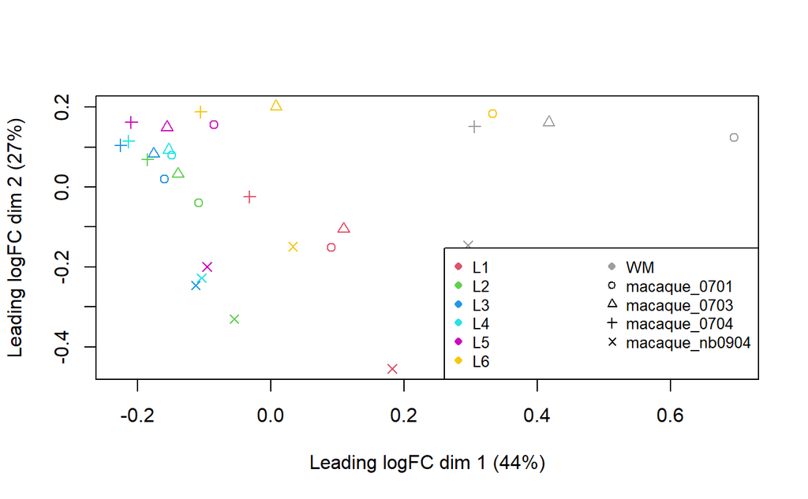

```r
layer <- as.factor(y$samples$layer)
sample_id <- y$samples$sample_id
plotMDS(y, pch=c(1:5)[sample_id], col=c(2:8)[layer])
legend("bottomright", legend=c(levels(layer), levels(sample_id)), pch=c(rep(16, 7), c(1:5)), col=c(c(2:8), rep(1, 5)), cex=0.8, ncol=2)
```

### Design matrix

```r
design <- model.matrix(~ 0 + layer + sample_id)
colnames(design) <- gsub("sample_id", "", colnames(design))
colnames(design) <- gsub("layer", "", colnames(design))
head(design)
```

```
  L1 L2 L3 L4 L5 L6 WM macaque_0703 macaque_0704 macaque_nb0904
1  1  0  0  0  0  0  0            0            0              0
2  1  0  0  0  0  0  0            1            0              0
3  1  0  0  0  0  0  0            0            1              0
4  1  0  0  0  0  0  0            0            0              1
5  0  1  0  0  0  0  0            0            0              0
6  0  1  0  0  0  0  0            1            0              0
```

### Dispersion estimation

```r
y <- estimateDisp(y, design, robust=TRUE)
y$common.dispersion
```

```
[1] 9.765625e-05
```

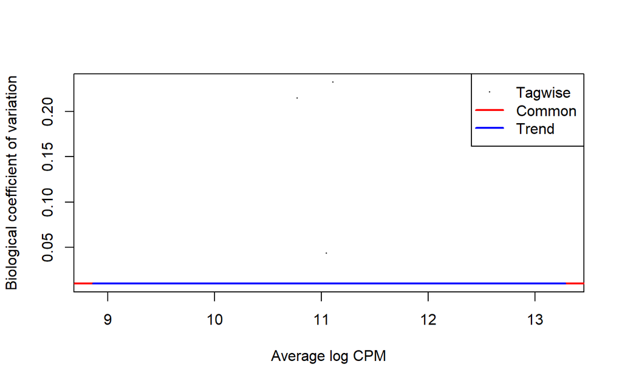

```r
plotBCV(y)
```

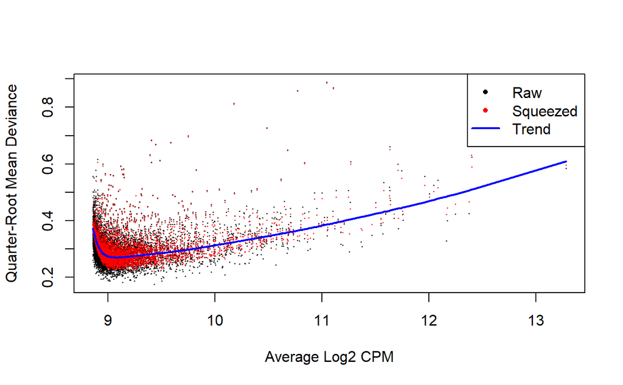

```r
fit <- glmQLFit(y, design, robust=TRUE, legacy=FALSE)
plotQLDisp(fit)
```

### Marker genes identification

Make a contrast matrix

```r
ncls <- nlevels(layer)
contr <- rbind( matrix(1 / (1 - ncls), ncls, ncls),
                matrix(0, ncol(design) - ncls, ncls)
              )
diag(contr) <- 1
rownames(contr) <- colnames(design)
colnames(contr) <- levels(layer)
contr
```

```
                       L1         L2         L3         L4         L5         L6         WM
L1              1.0000000 -0.1666667 -0.1666667 -0.1666667 -0.1666667 -0.1666667 -0.1666667
L2             -0.1666667  1.0000000 -0.1666667 -0.1666667 -0.1666667 -0.1666667 -0.1666667
L3             -0.1666667 -0.1666667  1.0000000 -0.1666667 -0.1666667 -0.1666667 -0.1666667
L4             -0.1666667 -0.1666667 -0.1666667  1.0000000 -0.1666667 -0.1666667 -0.1666667
L5             -0.1666667 -0.1666667 -0.1666667 -0.1666667  1.0000000 -0.1666667 -0.1666667
L6             -0.1666667 -0.1666667 -0.1666667 -0.1666667 -0.1666667  1.0000000 -0.1666667
WM             -0.1666667 -0.1666667 -0.1666667 -0.1666667 -0.1666667 -0.1666667  1.0000000
macaque_0703    0.0000000  0.0000000  0.0000000  0.0000000  0.0000000  0.0000000  0.0000000
macaque_0704    0.0000000  0.0000000  0.0000000  0.0000000  0.0000000  0.0000000  0.0000000
macaque_nb0904  0.0000000  0.0000000  0.0000000  0.0000000  0.0000000  0.0000000  0.0000000
```

Perform quasi-likelihood F-test

```r
qlf <- list()
for (i in 1:ncls){
  qlf[[i]] <- glmQLFTest(fit, contrast=contr[,i])
  qlf[[i]]$comparison <- paste0(levels(layer)[i], '_vs_others')
}
```

The top most significant DE genes for cluster L1

```r
topTags(qlf[[1]], n=10L)
```

```
Coefficient:  L1_vs_others
```

|  | logFC | logCPM | F | PValue | FDR |
| --- | --- | --- | --- | --- | --- |
| VIM | 2.969433 | 9.253603 | 863.4695 | 2.828565e-28 | 2.210240e-24 |
| PLPP3 | 1.216110 | 9.374182 | 297.9807 | 1.076072e-22 | 3.841749e-19 |
| CXCL14 | 2.941730 | 10.038736 | 721.0536 | 1.474949e-22 | 3.841749e-19 |
| HTRA1 | 1.204758 | 9.812221 | 352.1667 | 3.776472e-22 | 7.377339e-19 |
| SLC6A1 | 1.019567 | 10.112073 | 346.8104 | 7.447705e-22 | 1.163927e-18 |
| SLC1A3 | 1.565551 | 10.397817 | 541.6090 | 1.716550e-20 | 2.064482e-17 |
| FAM107A | 1.360626 | 9.455150 | 273.9616 | 1.849421e-20 | 2.064482e-17 |
| DCN | 1.981645 | 8.995390 | 380.9145 | 2.884205e-20 | 2.817147e-17 |
| ATP1A2 | 1.265342 | 9.585751 | 271.2508 | 3.396130e-20 | 2.948595e-17 |
| IGF2 | 2.765270 | 9.065342 | 573.5692 | 6.191508e-20 | 4.420411e-17 |

```r
for (i in 1:ncls){
  write.csv(qlf[[i]]$table, file=paste0('results/macaqueDE/degenes_', levels(layer)[i], '.csv'))
}
```

The numbers of DE genes under each comparison

```r
dt <- lapply(lapply(qlf, decideTestsDGE), summary)
dt.all <- do.call("cbind", dt)
dt.all
```

```
       L1_vs_others L2_vs_others L3_vs_others L4_vs_others L5_vs_others L6_vs_others WM_vs_others
Down            670          471          572          555          519          190         1393
NotSig         6363         6637         6179         6416         6571         7343         5213
Up              781          706         1063          843          724          281         1208
```

Let’s make a nice heatmap

```r
top <- 20
topMarkers <- list()
for (i in 1:ncls) {
  ord <- order(qlf[[i]]$table$PValue, decreasing=FALSE)
  up <- qlf[[i]]$table$logFC[ord] > 0
  topMarkers[[i]] <- rownames(y)[ord[up][1:top]]
}

topMarkers <- unique(unlist(topMarkers))
topMarkers
```

```
  [1] "VIM"       "PLPP3"     "CXCL14"    "HTRA1"     "SLC6A1"    "SLC1A3"    "FAM107A"   "DCN"
  [9] "ATP1A2"    "IGF2"      "S1PR1"     "PMP22"     "HAPLN1"    "IGFBP7"    "GLUL"      "FABP7"
 [17] "SLC1A2"    "PAQR8"     "ALDH1A1"   "GRM3"      "PENK"      "PCDH8"     "CALB2"     "SST"
 [25] "SERPINE2"  "NECTIN3"   "CDH13"     "ARPP19"    "CARTPT"    "SYT17"     "THBS1"     "CACNG3"
 [33] "VSTM2L"    "SMARCA2"   "DUSP4"     "CBLN2"     "SEC14L1"   "BCL6"      "HPCAL1"    "BHLHE40"
 [41] "LNX1"      "CAMK2A"    "CA10"      "ARPP21"    "ATP1A1"    "CHN1"      "RGS4"      "LRRC4C"
 [49] "FKBP1A"    "MEF2C"     "BNIP3"     "CYP46A1"   "LINGO1"    "SLC30A3"   "AP1S1"     "NRGN"
 [57] "BRINP1"    "HPCA"      "SATB1"     "SNCB"      "LDB2"      "NRSN1"     "KCNAB1"    "SH3GL2"
 [65] "DIRAS2"    "BMERB1"    "FBXW7"     "CHGA"      "NDRG4"     "SSBP3"     "PCSK1"     "SNCA"
 [73] "GABARAPL1" "TTC9B"     "CHN2"      "NRN1"      "PFKP"      "TUBA4A"    "NPTX1"     "TUSC3"
 [81] "SLC25A22"  "SLC17A7"   "TBR1"      "GOT1"      "ANXA6"     "TNNT1"     "SNAP25"    "NSF"
 [89] "SYT4"      "NELL1"     "RPRM"      "PLP1"      "TMEM178A"  "SULF1"     "GFAP"      "MBP"
 [97] "B3GALT2"   "KRT16"     "AGT"       "CPLX3"     "CXXC5"     "SEMA7A"    "KCNK1"     "SPOP"
[105] "ADD3"      "AQP4"      "BCAN"      "PTPRZ1"    "CNN3"      "B2M"       "MLC1"      "MAOB"
[113] "PZP"       "C3"        "PSAT1"     "DBI"       "TMBIM6"    "CNP"       "TSC22D4"
```

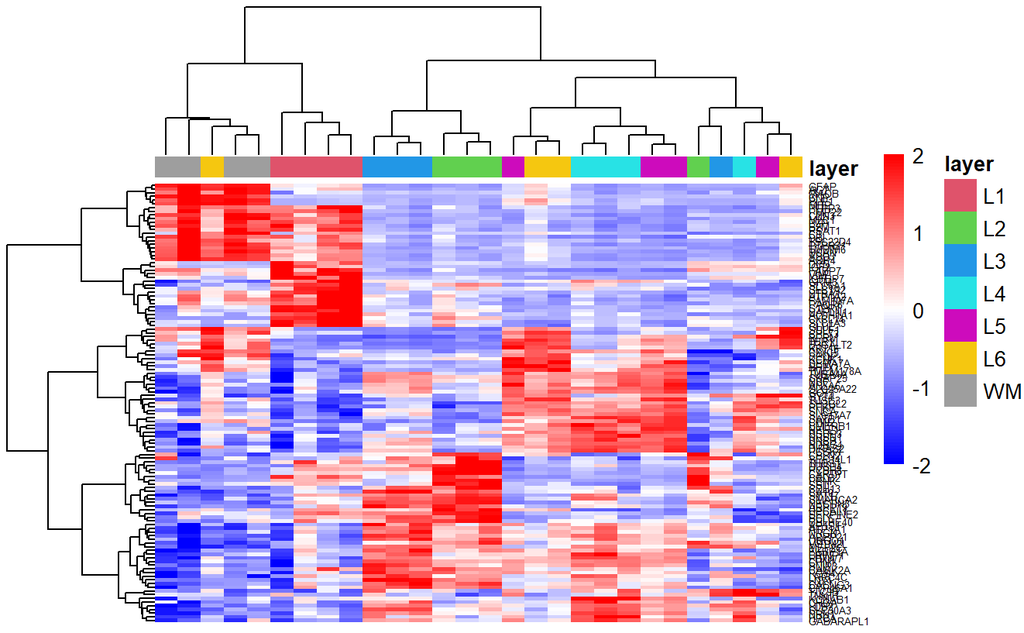

```r
lcpm <- cpm(y, log=TRUE)
annot <- data.frame(layer)
rownames(annot) <- colnames(y)
ann_colors <- list(layer=2:8)
names(ann_colors$layer) <- levels(layer)
pheatmap::pheatmap(lcpm[topMarkers,], breaks=seq(-2,2,length.out=101),
                   color=colorRampPalette(c("blue", "white", "red"))(100), scale="row",
                   ckuster_cols=TRUE, border_color="NA", fontsize_row=5,
                   treeheight_row=70, treeheight_col=70, cuttree_cols=7,
                   clustering_method="ward.D2", show_colnames=FALSE,
                   annotation_col=annot, annotation_colors=ann_colors)
```

## Adult Human markers

```r
expression <- read.csv('results/expression_adult.csv', header=TRUE, row.names=1)
head(expression)
```

|  | X151507_L1 | X151508_L1 | X151509_L1 | X151510_L1 | X151673_L1 | X151674_L1 | X151675_L1 | X151676_L1 | human_759_L1 | human_j12_L1 | human_j3_L1 | human_j4_L1 | human_j6_L1 | X151507_L2 | X151508_L2 | X151509_L2 | X151510_L2 | X151673_L2 | X151674_L2 | X151675_L2 | X151676_L2 | human_759_L2 | human_j12_L2 | human_j3_L2 | human_j4_L2 | human_j6_L2 | X151507_L3 | X151508_L3 | X151509_L3 | … |
| --- | --- | --- | --- | --- | --- | --- | --- | --- | --- | --- | --- | --- | --- | --- | --- | --- | --- | --- | --- | --- | --- | --- | --- | --- | --- | --- | --- | --- | --- | --- |
| A1BG | 0.087878786 | 0.04985755 | 0.064204045 | 0.067736186 | 0.058823530 | 0.132596690 | 0.03603604 | 0.071428575 | 0.144 | 0.145015100 | 0.1909091 | 0.252100860 | 0.06716418 | 0.175084170 | 0.203508760 | 0.158163260 | 0.185826780 | 0.222689080 | 0.24423963 | 0.193277310 | 0.21940929 | 0.450738900 | 0.760000000 | 1.47959180 | 0.735042750 | 0.22935780 | 0.113304720 | 0.113924050 | 0.152634440 | … |
| A1CF | 0.000000000 | 0.00000000 | 0.000000000 | 0.000000000 | 0.000000000 | 0.000000000 | 0.00000000 | 0.000000000 | 0.002 | 0.000000000 | 0.0000000 | 0.008403362 | 0.00000000 | 0.000000000 | 0.000000000 | 0.000000000 | 0.000000000 | 0.000000000 | 0.00000000 | 0.000000000 | 0.00000000 | 0.002463054 | 0.000000000 | 0.00000000 | 0.012820513 | 0.00000000 | 0.000000000 | 0.000000000 | 0.000000000 | … |
| A2M | 0.272727280 | 0.28490028 | 0.260334220 | 0.254901980 | 0.352941200 | 0.569060800 | 0.27027026 | 0.500000000 | 0.564 | 0.217522670 | 0.4181818 | 0.243697480 | 0.58955220 | 0.329966340 | 0.333333340 | 0.380952400 | 0.327559050 | 0.613445400 | 0.96774190 | 0.584033600 | 0.45147678 | 0.426108360 | 0.440000000 | 0.98979590 | 0.418803420 | 0.79816514 | 0.371673820 | 0.314082260 | 0.424225960 | … |
| A2ML1 | 0.004545454 | 0.01282051 | 0.007036060 | 0.002673797 | 0.004524887 | 0.005524862 | 0.00000000 | 0.000000000 | 0.010 | 0.000000000 | 0.0000000 | 0.000000000 | 0.00000000 | 0.000000000 | 0.000000000 | 0.003401361 | 0.004724409 | 0.008403362 | 0.00000000 | 0.004201681 | 0.00000000 | 0.009852217 | 0.000000000 | 0.00000000 | 0.004273504 | 0.00000000 | 0.004291845 | 0.001582279 | 0.005975014 | … |
| A4GALT | 0.006060606 | 0.00997151 | 0.009674583 | 0.004456328 | 0.004524887 | 0.019337017 | 0.01351351 | 0.005102041 | 0.004 | 0.009063444 | 0.0000000 | 0.000000000 | 0.01492537 | 0.003367003 | 0.007017544 | 0.003401361 | 0.006299213 | 0.012605042 | 0.02304148 | 0.021008404 | 0.02531646 | 0.009852217 | 0.005714286 | 0.01020408 | 0.008547009 | 0.02752294 | 0.006866953 | 0.003955696 | 0.006518197 | … |
| A4GNT | 0.000000000 | 0.00000000 | 0.000000000 | 0.000000000 | 0.000000000 | 0.000000000 | 0.00000000 | 0.000000000 | 0.000 | 0.000000000 | 0.0000000 | 0.000000000 | 0.00000000 | 0.000000000 | 0.000000000 | 0.000000000 | 0.000000000 | 0.000000000 | 0.00000000 | 0.000000000 | 0.00000000 | 0.000000000 | 0.000000000 | 0.00000000 | 0.000000000 | 0.00000000 | 0.000000000 | 0.000000000 | 0.000000000 | … |

```r
annotation <- read.csv("results/annotation_adult.csv", header=TRUE, row.names=1)
head(annotation)
```

|  | layer | sample_id | psbulk_n_cells | psbulk_counts | condition | layer_c |
| --- | --- | --- | --- | --- | --- | --- |
| 151507_L1 | L1 | 151507 | 660 | 952011 | spatial_libd_human | 1 |
| 151508_L1 | L1 | 151508 | 702 | 831032 | spatial_libd_human | 1 |
| 151509_L1 | L1 | 151509 | 1137 | 1593570 | spatial_libd_human | 1 |
| 151510_L1 | L1 | 151510 | 1122 | 1484205 | spatial_libd_human | 1 |
| 151673_L1 | L1 | 151673 | 221 | 399606 | spatial_libd_human | 1 |
| 151674_L1 | L1 | 151674 | 362 | 1085134 | spatial_libd_human | 1 |

### Prepare the data

Let’s filter human samples in expression and annotation dataframes

```r
human_ann <- annotation[annotation$condition == 'spatial_libd_human',]
head(human_ann)
```

|  | layer | sample_id | psbulk_n_cells | psbulk_counts | condition | layer_c |
| --- | --- | --- | --- | --- | --- | --- |
| 151507_L1 | L1 | 151507 | 660 | 952011 | spatial_libd_human | 1 |
| 151508_L1 | L1 | 151508 | 702 | 831032 | spatial_libd_human | 1 |
| 151509_L1 | L1 | 151509 | 1137 | 1593570 | spatial_libd_human | 1 |
| 151510_L1 | L1 | 151510 | 1122 | 1484205 | spatial_libd_human | 1 |
| 151673_L1 | L1 | 151673 | 221 | 399606 | spatial_libd_human | 1 |
| 151674_L1 | L1 | 151674 | 362 | 1085134 | spatial_libd_human | 1 |

```r
human_expr <- expression[, paste0("X", row.names(human_ann))]
head(human_expr)
```

|  | X151507_L1 | X151508_L1 | X151509_L1 | X151510_L1 | X151673_L1 | X151674_L1 | X151675_L1 | X151676_L1 | X151507_L2 | X151508_L2 | X151509_L2 | X151510_L2 | X151673_L2 | X151674_L2 | X151675_L2 | X151676_L2 | X151507_L3 | X151508_L3 | X151509_L3 | X151510_L3 | X151669_L3 | X151670_L3 | X151671_L3 | X151672_L3 | X151673_L3 | X151674_L3 | X151675_L3 | X151676_L3 | X151507_L4 | … |
| --- | --- | --- | --- | --- | --- | --- | --- | --- | --- | --- | --- | --- | --- | --- | --- | --- | --- | --- | --- | --- | --- | --- | --- | --- | --- | --- | --- | --- | --- | --- |
| A1BG | 0.087878786 | 0.04985755 | 0.064204045 | 0.067736186 | 0.058823530 | 0.132596690 | 0.03603604 | 0.071428575 | 0.175084170 | 0.203508760 | 0.158163260 | 0.185826780 | 0.222689080 | 0.24423963 | 0.193277310 | 0.21940929 | 0.113304720 | 0.113924050 | 0.152634440 | 0.147806000 | 0.123056990 | 0.124916500 | 0.141630900 | 0.154801320 | 0.169527900 | 0.24215247 | 0.168421060 | 0.17656012 | 0.125698330 | … |
| A1CF | 0.000000000 | 0.00000000 | 0.000000000 | 0.000000000 | 0.000000000 | 0.000000000 | 0.00000000 | 0.000000000 | 0.000000000 | 0.000000000 | 0.000000000 | 0.000000000 | 0.000000000 | 0.00000000 | 0.000000000 | 0.00000000 | 0.000000000 | 0.000000000 | 0.000000000 | 0.000000000 | 0.000000000 | 0.000000000 | 0.000000000 | 0.000000000 | 0.000000000 | 0.00000000 | 0.000000000 | 0.00000000 | 0.000000000 | … |
| A2M | 0.272727280 | 0.28490028 | 0.260334220 | 0.254901980 | 0.352941200 | 0.569060800 | 0.27027026 | 0.500000000 | 0.329966340 | 0.333333340 | 0.380952400 | 0.327559050 | 0.613445400 | 0.96774190 | 0.584033600 | 0.45147678 | 0.371673820 | 0.314082260 | 0.424225960 | 0.379907600 | 0.349740920 | 0.281897130 | 0.350500700 | 0.276490060 | 0.645922700 | 0.91031390 | 0.521052660 | 0.61035010 | 0.354748600 | … |
| A2ML1 | 0.004545454 | 0.01282051 | 0.007036060 | 0.002673797 | 0.004524887 | 0.005524862 | 0.00000000 | 0.000000000 | 0.000000000 | 0.000000000 | 0.003401361 | 0.004724409 | 0.008403362 | 0.00000000 | 0.004201681 | 0.00000000 | 0.004291845 | 0.001582279 | 0.005975014 | 0.004041570 | 0.005181347 | 0.004676019 | 0.003576538 | 0.007450331 | 0.005364807 | 0.01121076 | 0.001754386 | 0.00304414 | 0.002793296 | … |
| A4GALT | 0.006060606 | 0.00997151 | 0.009674583 | 0.004456328 | 0.004524887 | 0.019337017 | 0.01351351 | 0.005102041 | 0.003367003 | 0.007017544 | 0.003401361 | 0.006299213 | 0.012605042 | 0.02304148 | 0.021008404 | 0.02531646 | 0.006866953 | 0.003955696 | 0.006518197 | 0.006928407 | 0.007772020 | 0.004008016 | 0.004291845 | 0.005794702 | 0.009656653 | 0.01569507 | 0.007017544 | 0.01369863 | 0.002793296 | … |
| A4GNT | 0.000000000 | 0.00000000 | 0.000000000 | 0.000000000 | 0.000000000 | 0.000000000 | 0.00000000 | 0.000000000 | 0.000000000 | 0.000000000 | 0.000000000 | 0.000000000 | 0.000000000 | 0.00000000 | 0.000000000 | 0.00000000 | 0.000000000 | 0.000000000 | 0.000000000 | 0.000000000 | 0.000000000 | 0.000000000 | 0.000000000 | 0.000000000 | 0.000000000 | 0.00000000 | 0.000000000 | 0.00000000 | 0.000000000 | … |

```r
NA
```

Factor the data

```r
human_ann$layer <- factor(human_ann$layer)
human_ann$sample_id <- factor(human_ann$sample_id)
head(human_ann)
```

|  | layer | sample_id | psbulk_n_cells | psbulk_counts | condition | layer_c |
| --- | --- | --- | --- | --- | --- | --- |
| 151507_L1 | L1 | 151507 | 660 | 952011 | spatial_libd_human | 1 |
| 151508_L1 | L1 | 151508 | 702 | 831032 | spatial_libd_human | 1 |
| 151509_L1 | L1 | 151509 | 1137 | 1593570 | spatial_libd_human | 1 |
| 151510_L1 | L1 | 151510 | 1122 | 1484205 | spatial_libd_human | 1 |
| 151673_L1 | L1 | 151673 | 221 | 399606 | spatial_libd_human | 1 |
| 151674_L1 | L1 | 151674 | 362 | 1085134 | spatial_libd_human | 1 |

```r
y <- DGEList(counts=human_expr, samples=human_ann)
y
```

```
An object of class "DGEList"
$counts
        X151507_L1 X151508_L1  X151509_L1  X151510_L1  X151673_L1  X151674_L1 X151675_L1  X151676_L1
A1BG   0.087878786 0.04985755 0.064204045 0.067736186 0.058823530 0.132596690 0.03603604 0.071428575
A1CF   0.000000000 0.00000000 0.000000000 0.000000000 0.000000000 0.000000000 0.00000000 0.000000000
A2M    0.272727280 0.28490028 0.260334220 0.254901980 0.352941200 0.569060800 0.27027026 0.500000000
A2ML1  0.004545454 0.01282051 0.007036060 0.002673797 0.004524887 0.005524862 0.00000000 0.000000000
A4GALT 0.006060606 0.00997151 0.009674583 0.004456328 0.004524887 0.019337017 0.01351351 0.005102041
        X151507_L2  X151508_L2  X151509_L2  X151510_L2  X151673_L2 X151674_L2  X151675_L2 X151676_L2
A1BG   0.175084170 0.203508760 0.158163260 0.185826780 0.222689080 0.24423963 0.193277310 0.21940929
A1CF   0.000000000 0.000000000 0.000000000 0.000000000 0.000000000 0.00000000 0.000000000 0.00000000
A2M    0.329966340 0.333333340 0.380952400 0.327559050 0.613445400 0.96774190 0.584033600 0.45147678
A2ML1  0.000000000 0.000000000 0.003401361 0.004724409 0.008403362 0.00000000 0.004201681 0.00000000
A4GALT 0.003367003 0.007017544 0.003401361 0.006299213 0.012605042 0.02304148 0.021008404 0.02531646
        X151507_L3  X151508_L3  X151509_L3  X151510_L3  X151669_L3  X151670_L3  X151671_L3  X151672_L3
A1BG   0.113304720 0.113924050 0.152634440 0.147806000 0.123056990 0.124916500 0.141630900 0.154801320
A1CF   0.000000000 0.000000000 0.000000000 0.000000000 0.000000000 0.000000000 0.000000000 0.000000000
A2M    0.371673820 0.314082260 0.424225960 0.379907600 0.349740920 0.281897130 0.350500700 0.276490060
A2ML1  0.004291845 0.001582279 0.005975014 0.004041570 0.005181347 0.004676019 0.003576538 0.007450331
A4GALT 0.006866953 0.003955696 0.006518197 0.006928407 0.007772020 0.004008016 0.004291845 0.005794702
        X151673_L3 X151674_L3  X151675_L3 X151676_L3  X151507_L4  X151508_L4  X151509_L4 X151510_L4
A1BG   0.169527900 0.24215247 0.168421060 0.17656012 0.125698330 0.107344635 0.111420620  0.1419355
A1CF   0.000000000 0.00000000 0.000000000 0.00000000 0.000000000 0.000000000 0.000000000  0.0000000
A2M    0.645922700 0.91031390 0.521052660 0.61035010 0.354748600 0.313559320 0.353760450  0.2935484
A2ML1  0.005364807 0.01121076 0.001754386 0.00304414 0.002793296 0.005649718 0.002785515  0.0000000
A4GALT 0.009656653 0.01569507 0.007017544 0.01369863 0.002793296 0.002824859 0.005571030  0.0000000
       X151669_L4 X151670_L4  X151671_L4  X151672_L4  X151673_L4 X151674_L4 X151675_L4  X151676_L4
A1BG   0.15838510  0.1046512 0.259433950 0.181069960 0.129186600  0.2259414 0.12328767 0.162280710
A1CF   0.00000000  0.0000000 0.000000000 0.000000000 0.000000000  0.0000000 0.00000000 0.000000000
A2M    0.55279505  0.3779070 0.462264150 0.382716060 0.473684220  0.8661088 0.46118720 0.495614020
A2ML1  0.00000000  0.0000000 0.000000000 0.004115226 0.009569378  0.0041841 0.00456621 0.000000000
A4GALT 0.02173913  0.0000000 0.004716981 0.000000000 0.014354067  0.0167364 0.00913242 0.004385965
        X151507_L5  X151508_L5  X151509_L5  X151510_L5  X151669_L5  X151670_L5  X151671_L5  X151672_L5
A1BG   0.150227620 0.111731840 0.101408450 0.132890360 0.269387750 0.201478750 0.208516880 0.220088630
A1CF   0.000000000 0.000000000 0.000000000 0.000000000 0.000000000 0.000000000 0.000000000 0.000000000
A2M    0.336874040 0.273743000 0.276056350 0.398671100 0.457142860 0.397412200 0.437591800 0.376661750
A2ML1  0.003034901 0.002793296 0.016901410 0.003322259 0.002040816 0.009242144 0.001468429 0.005908419
A4GALT 0.009104704 0.005586592 0.008450705 0.006644518 0.012244898 0.001848429 0.016152717 0.007385524
       X151673_L5  X151674_L5 X151675_L5  X151676_L5  X151507_L6  X151508_L6  X151509_L6 X151510_L6
A1BG   0.15068494 0.244628100 0.13138686 0.125401930 0.147679330 0.101960786 0.062500000 0.09714286
```

[output cut: 10 more lines]

```
        X151507_WM  X151508_WM X151509_WM  X151510_WM  X151669_WM X151670_WM  X151671_WM  X151672_WM
A1BG   0.107246380 0.086734700    0.29375 0.189944130 0.188679250  0.1286550 0.048054920 0.046272494
A1CF   0.000000000 0.000000000    0.00000 0.000000000 0.000000000  0.0000000 0.000000000 0.000000000
A2M    0.214492750 0.173469400    0.41250 0.363128480 0.259433950  0.2923977 0.093821510 0.092544990
A2ML1  0.000000000 0.000000000    0.00000 0.005586592 0.000000000  0.0000000 0.002288329 0.000000000
A4GALT 0.002898551 0.005102041    0.00625 0.005586592 0.004716981  0.0000000 0.000000000 0.002570694
       X151673_WM  X151674_WM  X151675_WM  X151676_WM
A1BG        0.358 0.344827600 0.221519000 0.211946060
A1CF        0.000 0.000000000 0.000000000 0.000000000
A2M         0.400 0.574712630 0.311708870 0.404624280
A2ML1       0.008 0.003284072 0.003164557 0.007707129
A4GALT      0.008 0.024630541 0.004746835 0.005780347
17914 more rows ...

$samples
```

|  | group | lib.size | norm.factors | layer | sample_id | psbulk_n_cells | psbulk_counts | condition | layer_c |
| --- | --- | --- | --- | --- | --- | --- | --- | --- | --- |
| X151507_L1 | 1 | 1442.441 | 1 | L1 | 151507 | 660 | 952011 | spatial_libd_human | 1 |
| X151508_L1 | 1 | 1183.806 | 1 | L1 | 151508 | 702 | 831032 | spatial_libd_human | 1 |
| X151509_L1 | 1 | 1401.557 | 1 | L1 | 151509 | 1137 | 1593570 | spatial_libd_human | 1 |
| X151510_L1 | 1 | 1322.821 | 1 | L1 | 151510 | 1122 | 1484205 | spatial_libd_human | 1 |
| X151673_L1 | 1 | 1808.172 | 1 | L1 | 151673 | 221 | 399606 | spatial_libd_human | 1 |

```
71 more rows ...
```

### Filtering and normalization

Let’s check a summary table

```r
summary(human_ann)
```

```
 layer     sample_id  psbulk_n_cells   psbulk_counts      condition            layer_c
 L1: 8   151507 : 7   Min.   : 160.0   Min.   : 183824   Length:76          Min.   :1.000
 L2: 8   151508 : 7   1st Qu.: 238.8   1st Qu.: 851688   Class :character   1st Qu.:3.000
 L3:12   151509 : 7   Median : 495.0   Median :1491132   Mode  :character   Median :4.000
 L4:12   151510 : 7   Mean   : 560.4   Mean   :1926390                      Mean   :4.263
 L5:12   151673 : 7   3rd Qu.: 675.5   3rd Qu.:2791973                      3rd Qu.:6.000
 L6:12   151674 : 7   Max.   :1841.0   Max.   :6502280                      Max.   :7.000
 WM:12   (Other):34
```

Now filter out low expressed genes

```r
keep.genes <- filterByExpr(y, group=y$samples$layer, min.count=0.01, min.total.count=1)
table(keep.genes)
```

```
keep.genes
FALSE  TRUE
 5979 11940
```

```r
y <- y[keep.genes, , keep=FALSE]
```

TMM normalization

```r
y <- normLibSizes(y)
head(y$samples, n=10L)
```

|  | group | lib.size | norm.factors | layer | sample_id | psbulk_n_cells | psbulk_counts | condition | layer_c |
| --- | --- | --- | --- | --- | --- | --- | --- | --- | --- |
| X151507_L1 | 1 | 1432.102 | 0.9190771 | L1 | 151507 | 660 | 952011 | spatial_libd_human | 1 |
| X151508_L1 | 1 | 1175.328 | 0.9157156 | L1 | 151508 | 702 | 831032 | spatial_libd_human | 1 |
| X151509_L1 | 1 | 1391.524 | 0.9662105 | L1 | 151509 | 1137 | 1593570 | spatial_libd_human | 1 |
| X151510_L1 | 1 | 1313.648 | 0.9580160 | L1 | 151510 | 1122 | 1484205 | spatial_libd_human | 1 |
| X151673_L1 | 1 | 1795.226 | 1.0470983 | L1 | 151673 | 221 | 399606 | spatial_libd_human | 1 |
| X151674_L1 | 1 | 2973.948 | 1.0748801 | L1 | 151674 | 362 | 1085134 | spatial_libd_human | 1 |
| X151675_L1 | 1 | 1523.023 | 1.0353102 | L1 | 151675 | 222 | 340444 | spatial_libd_human | 1 |
| X151676_L1 | 1 | 2371.347 | 1.0225549 | L1 | 151676 | 196 | 467871 | spatial_libd_human | 1 |
| X151507_L2 | 1 | 2982.599 | 0.9737610 | L2 | 151507 | 297 | 890323 | spatial_libd_human | 2 |
| X151508_L2 | 1 | 2496.379 | 0.9693107 | L2 | 151508 | 285 | 715155 | spatial_libd_human | 2 |

```r
summary(y$samples$norm.factors)
```

```
   Min. 1st Qu.  Median    Mean 3rd Qu.    Max.
 0.9157  0.9634  1.0045  1.0010  1.0323  1.0886
```

### Data exploration

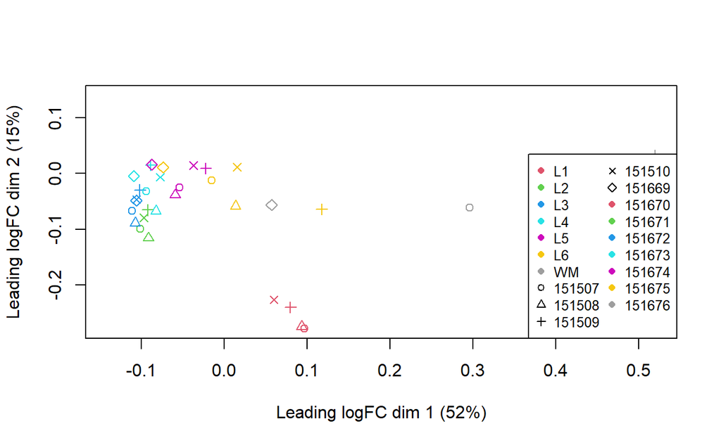

```r
layer <- as.factor(y$samples$layer)
sample_id <- y$samples$sample_id
plotMDS(y, pch=c(1:5)[sample_id], col=c(2:8)[layer])
legend("bottomright", legend=c(levels(layer), levels(sample_id)), pch=c(rep(16, 7), c(1:5)), col=c(c(2:8), rep(1, 5)), cex=0.8, ncol=2)
```

### Design matrix

```r
design <- model.matrix(~ 0 + layer + sample_id)
colnames(design) <- gsub("sample_id", "", colnames(design))
colnames(design) <- gsub("layer", "", colnames(design))
head(design)
```

```
  L1 L2 L3 L4 L5 L6 WM 151508 151509 151510 151669 151670 151671 151672 151673 151674 151675 151676
1  1  0  0  0  0  0  0      0      0      0      0      0      0      0      0      0      0      0
2  1  0  0  0  0  0  0      1      0      0      0      0      0      0      0      0      0      0
3  1  0  0  0  0  0  0      0      1      0      0      0      0      0      0      0      0      0
4  1  0  0  0  0  0  0      0      0      1      0      0      0      0      0      0      0      0
5  1  0  0  0  0  0  0      0      0      0      0      0      0      0      1      0      0      0
6  1  0  0  0  0  0  0      0      0      0      0      0      0      0      0      1      0      0
```

### Dispersion estimation

```r
y <- estimateDisp(y, design, robust=TRUE)
y$common.dispersion
```

```
[1] 9.765625e-05
```

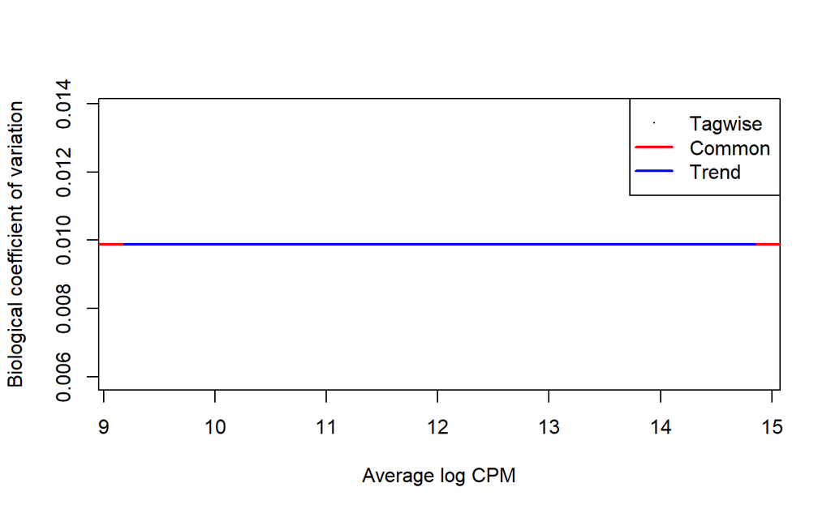

```r
plotBCV(y)
```

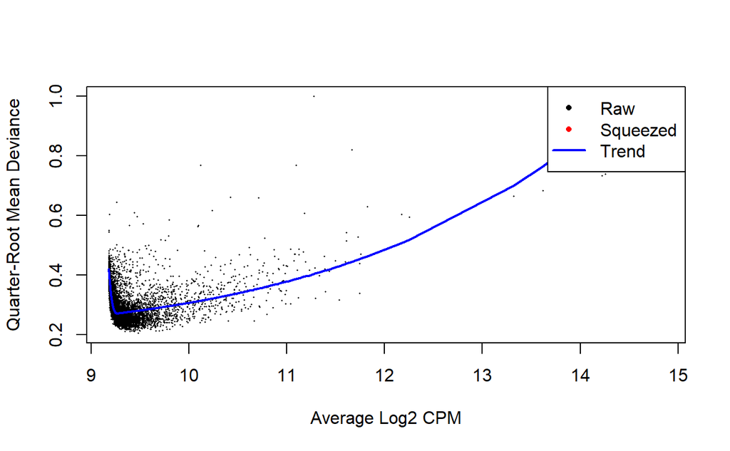

```r
fit <- glmQLFit(y, design, robust=TRUE, legacy=FALSE)
plotQLDisp(fit)
```

### Marker genes identification

Make a contrast matrix

```r
ncls <- nlevels(layer)
contr <- rbind( matrix(1 / (1 - ncls), ncls, ncls),
                matrix(0, ncol(design) - ncls, ncls)
              )
diag(contr) <- 1
rownames(contr) <- colnames(design)
colnames(contr) <- levels(layer)
contr
```

```
               L1         L2         L3         L4         L5         L6         WM
L1      1.0000000 -0.1666667 -0.1666667 -0.1666667 -0.1666667 -0.1666667 -0.1666667
L2     -0.1666667  1.0000000 -0.1666667 -0.1666667 -0.1666667 -0.1666667 -0.1666667
L3     -0.1666667 -0.1666667  1.0000000 -0.1666667 -0.1666667 -0.1666667 -0.1666667
L4     -0.1666667 -0.1666667 -0.1666667  1.0000000 -0.1666667 -0.1666667 -0.1666667
L5     -0.1666667 -0.1666667 -0.1666667 -0.1666667  1.0000000 -0.1666667 -0.1666667
L6     -0.1666667 -0.1666667 -0.1666667 -0.1666667 -0.1666667  1.0000000 -0.1666667
WM     -0.1666667 -0.1666667 -0.1666667 -0.1666667 -0.1666667 -0.1666667  1.0000000
151508  0.0000000  0.0000000  0.0000000  0.0000000  0.0000000  0.0000000  0.0000000
151509  0.0000000  0.0000000  0.0000000  0.0000000  0.0000000  0.0000000  0.0000000
151510  0.0000000  0.0000000  0.0000000  0.0000000  0.0000000  0.0000000  0.0000000
151669  0.0000000  0.0000000  0.0000000  0.0000000  0.0000000  0.0000000  0.0000000
151670  0.0000000  0.0000000  0.0000000  0.0000000  0.0000000  0.0000000  0.0000000
151671  0.0000000  0.0000000  0.0000000  0.0000000  0.0000000  0.0000000  0.0000000
151672  0.0000000  0.0000000  0.0000000  0.0000000  0.0000000  0.0000000  0.0000000
151673  0.0000000  0.0000000  0.0000000  0.0000000  0.0000000  0.0000000  0.0000000
151674  0.0000000  0.0000000  0.0000000  0.0000000  0.0000000  0.0000000  0.0000000
151675  0.0000000  0.0000000  0.0000000  0.0000000  0.0000000  0.0000000  0.0000000
151676  0.0000000  0.0000000  0.0000000  0.0000000  0.0000000  0.0000000  0.0000000
```

Perform quasi-likelihood F-test

```r
qlf <- list()
for (i in 1:ncls){
  qlf[[i]] <- glmQLFTest(fit, contrast=contr[,i])
  qlf[[i]]$comparison <- paste0(levels(layer)[i], '_vs_others')
}
```

The top most significant DE genes for cluster L1

```r
topTags(qlf[[1]], n=10L)
```

```
Coefficient:  L1_vs_others
```

|  | logFC | logCPM | F | PValue | FDR |
| --- | --- | --- | --- | --- | --- |
| GFAP | 1.450824 | 10.425158 | 1503.9971 | 0.000000e+00 | 0.000000e+00 |
| CXCL14 | 1.458900 | 9.594410 | 985.1156 | 4.384590e-216 | 2.617600e-212 |
| MGP | 1.297376 | 9.796390 | 909.6542 | 1.054436e-199 | 4.196657e-196 |
| VIM | 1.405922 | 9.559869 | 781.2145 | 8.171053e-172 | 2.439059e-168 |
| MYL9 | 1.550131 | 9.290811 | 639.4890 | 5.004471e-141 | 1.195068e-137 |
| MT1G | 1.340633 | 9.415498 | 562.8554 | 2.255726e-124 | 4.488895e-121 |
| SNORC | 1.274111 | 9.466902 | 551.4350 | 6.849065e-122 | 1.168255e-118 |
| AQP4 | 1.226650 | 9.530022 | 549.9949 | 1.408258e-121 | 2.101825e-118 |
| SPARC | 1.138340 | 9.525153 | 512.4527 | 2.041197e-113 | 2.707988e-110 |
| FABP7 | 1.387791 | 9.318122 | 506.3004 | 4.440958e-112 | 5.302504e-109 |

```r
for (i in 1:ncls){
  write.csv(qlf[[i]]$table, file=paste0('results/adultsDE/degenes_', levels(layer)[i], '.csv'))
}
```

The numbers of DE genes under each comparison

```r
dt <- lapply(lapply(qlf, decideTestsDGE), summary)
dt.all <- do.call("cbind", dt)
dt.all
```

```
       L1_vs_others L2_vs_others L3_vs_others L4_vs_others L5_vs_others L6_vs_others WM_vs_others
Down            736         1198          944          972          893          453         2828
NotSig        10441         9369         9659         9517         9751        10703         6591
Up              763         1373         1337         1451         1296          784         2521
```

Let’s make a nice heatmap

```r
top <- 20
topMarkers <- list()
for (i in 1:ncls) {
  ord <- order(qlf[[i]]$table$PValue, decreasing=FALSE)
  up <- qlf[[i]]$table$logFC[ord] > 0
  topMarkers[[i]] <- rownames(y)[ord[up][1:top]]
}

topMarkers <- unique(unlist(topMarkers))
topMarkers
```

```
  [1] "GFAP"     "CXCL14"   "MGP"      "VIM"      "MYL9"     "MT1G"     "SNORC"    "AQP4"     "SPARC"
 [10] "FABP7"    "RELN"     "TAGLN"    "CST3"     "ACTA2"    "AGT"      "MT2A"     "SLC1A2"   "ADIRF"
 [19] "METRN"    "SAA1"     "HPCAL1"   "ENC1"     "HOPX"     "SERPINE2" "C1QL2"    "CAMK2N1"  "LAMP5"
 [28] "PCDH8"    "ITPKA"    "PPP3CA"   "CALB2"    "CNR1"     "SOWAHA"   "CALB1"    "NCDN"     "CARTPT"
 [37] "NPTXR"    "EGR3"     "CUX2"     "NEFM"     "NEFL"     "YWHAH"    "SNCG"     "CBLN4"    "HAPLN4"
 [46] "LMO4"     "GAP43"    "TESPA1"   "ADCYAP1"  "VSTM2A"   "OLFM1"    "GPX3"     "NEFH"     "PVALB"
 [55] "SCN1B"    "VAMP1"    "RORB"     "PARM1"    "FRMPD2"   "STMN2"    "DCLK1"    "LGALS1"   "CHGA"
 [64] "INA"      "TUBA1B"   "VGF"      "GABRA1"   "PCP4"     "TMSB10"   "TUBB2A"   "SYT1"     "SMYD2"
 [73] "HS3ST2"   "CAMK2D"   "CLSTN2"   "SNAP25"   "PFKP"     "EFHD2"    "SYN2"     "IPCEF1"   "NDRG4"
 [82] "DIRAS2"   "VAT1L"    "KRT17"    "PLP1"     "MBP"      "B3GALT2"  "SCGB2A2"  "TF"       "TBR1"
 [91] "NR4A2"    "SEMA3E"   "SCGB1D2"  "MOBP"     "SLC35F1"  "NPTX1"    "MAP2K1"   "SLC17A7"  "ABCA2"
[100] "ANLN"     "APOD"     "BCAS1"    "CARNS1"   "CERCAM"   "CLDN11"   "CLDND1"   "CNDP1"    "CNP"
[109] "CNTN2"    "CRYAB"    "CSRP1"    "EDIL3"    "EFHD1"    "ELOVL1"   "ENPP2"    "ERMN"     "EVI2A"
[118] "FA2H"
```

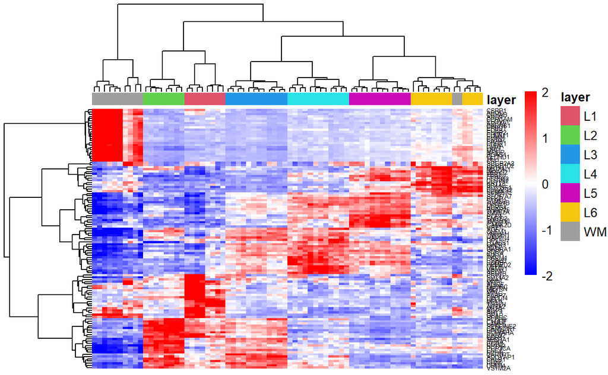

```r
lcpm <- cpm(y, log=TRUE)
annot <- data.frame(layer)
rownames(annot) <- colnames(y)
ann_colors <- list(layer=2:8)
names(ann_colors$layer) <- levels(layer)
pheatmap::pheatmap(lcpm[topMarkers,], breaks=seq(-2,2,length.out=101),
                   color=colorRampPalette(c("blue", "white", "red"))(100), scale="row",
                   ckuster_cols=TRUE, border_color="NA", fontsize_row=5,
                   treeheight_row=70, treeheight_col=70, cuttree_cols=7,
                   clustering_method="ward.D2", show_colnames=FALSE,
                   annotation_col=annot, annotation_colors=ann_colors)
```